# Forecasting 2024 Global Happiness Trends: Exploring the Impact of Cumulative Socio-Economic Influences

## Overview

In our project, titled "**Forecasting 2024 Global Happiness Trends: Exploring the Impact of Cumulative Socio-Economic Influences**," our team aims to analyze and predict happiness trends worldwide for the year 2024. We will explore how various socio-economic factors influence happiness levels across different countries, utilizing comprehensive datasets spanning from 2020 to 2023, focusing on **GDP**, **layoff statistics**, **income group classifications**, and reports on **global well-being**.

Our primary objective is **to understand the cumulative impact of socio-economic indicators on future happiness trends**. To accomplish this, we will begin by merging the different datasets. This step involves integrating the data from multiple sources using common identifiers such as country names or codes. By merging the datasets, we ensure that all relevant information is consolidated into a single cohesive dataset, facilitating further analysis. Following data merging, we'll employ Python libraries such as *pandas*, *NumPy*, *Matplotlib*, *Seaborn*, and others for data manipulation and visualization. This phase will involve preprocessing the merged dataset to handle missing values, outliers, and inconsistencies. Subsequently, we will conduct exploratory data analysis to gain insights into the distributions, trends, and interrelationships within the data.

Once we have thoroughly explored the datasets and gained valuable insights, we will proceed to develop predictive models. We will employ advanced statistical techniques and machine learning algorithms such as clustering, regression analysis, random forests, et cetera to forecast happiness scores for 2024 based on the socio-economic factors identified in our analysis.

Throughout the project, our team will maintain a multidisciplinary approach, combining expertise in data analysis, econometrics, and social sciences. We will evaluate the performance of our predictive models using appropriate metrics and validate their accuracy through cross-validation techniques.

Ultimately, our project aims to contribute valuable insights into the complex interplay between socio-economic conditions and global happiness levels. By forecasting future happiness trends, we hope to inform policymakers, researchers, and stakeholders about the potential long-term implications of socio-economic policies on societal well-being. Our findings may aid in the development of evidence-based strategies to promote happiness and improve the quality of life for individuals and communities worldwide.

## Motivation

Our team selected the topic of "**Forecasting 2024 Global Happiness Trends: Exploring the Impact of Cumulative Socio-Economic Influences**" due to its relevance and significance in understanding societal well-being and the factors that contribute to it. We believe that happiness is a crucial aspect of human life, and gaining insights into the drivers of happiness can inform policies and interventions aimed at promoting overall societal welfare.

One of the primary reasons for choosing this topic is its interdisciplinary nature. By integrating socio-economic factors such as GDP, layoff statistics, and income group classifications, along with reports on global well-being, we aim to examine the complex interplay between various determinants of happiness. This holistic approach allows us to explore how economic conditions, employment stability, income distribution, social support, and other socio-economic indicators collectively influence happiness levels across different countries.

In the course of our project, we have generated three real-world questions about the data:

1. **How do changes in GDP impact happiness levels across different countries over time?** By analyzing the relationship between GDP fluctuations and happiness scores, we hope to understand the extent to which economic growth contributes to overall well-being. This question will provide insights into whether increases in GDP translate into higher happiness levels and whether there are disparities in this relationship among countries.
2. **What is the relationship between layoff rates and happiness levels?** Investigating the correlation between layoff rates and happiness levels will shed light on the psychological and emotional impact of job insecurity on individuals and communities. Understanding how employment stability affects happiness can inform labor market policies and interventions aimed at mitigating the adverse effects of layoffs on well-being.
3. **Do income group classifications correlate with happiness scores, and if so, how?** Exploring the relationship between income group classifications and happiness scores will help us understand the role of income inequality in shaping subjective well-being. By examining whether individuals in different income groups report varying levels of happiness, we aim to identify potential socio-economic disparities in happiness and inform policies aimed at reducing inequality and promoting social inclusion.

Through these questions, we hope to gain valuable insights into the mechanisms underlying global happiness trends and the socio-economic factors that contribute to them. By answering these questions, our project aims to provide evidence-based recommendations to policymakers, researchers, and stakeholders to enhance overall societal well-being and quality of life.

## Data Sources

1. [Global GDP Growth Rate 2020-2023](https://www.imf.org/external/datamapper/NGDP_RPCH@WEO/OEMDC/ADVEC/WEOWORLD)
2. [Global Layoffs 2020-2023](https://www.kaggle.com/datasets/swaptr/layoffs-2022)
3. [World Income Groups 2022](https://www.kaggle.com/datasets/willianoliveiragibin/world-gdp-by-country-region-and-income-group)
4. [World Happiness Report (2020-2022)](https://www.kaggle.com/datasets/mathurinache/world-happiness-report) | [World Happiness Report 2023](https://www.kaggle.com/datasets/ajaypalsinghlo/world-happiness-report-2023)

The datasets selected for this analysis offer complementary perspectives on global socio-economic trends, providing a comprehensive understanding of the factors influencing happiness levels worldwide. The Global GDP Growth Rate dataset from the International Monetary Fund (IMF) offers insights into the economic performance of countries over the period 2020-2023, highlighting variations in economic growth rates across different regions. This information is complemented by the Global Layoffs dataset, sourced from Kaggle, which provides crucial insights into labor market dynamics and employment trends during the same period. Additionally, the World Income Groups dataset further enriches the analysis by categorizing countries into income groups, allowing for a nuanced examination of how economic disparities may impact happiness levels. Finally, the World Happiness Report datasets offer direct measures of subjective well-being, providing valuable context for understanding the socio-economic factors that contribute to happiness trends. By integrating these datasets, we can gain a holistic understanding of the interplay between economic performance, employment dynamics, income distribution, and subjective well-being, ultimately informing evidence-based strategies for promoting global happiness and well-being.

# Project Part I - Data Description & Manipulation

## Data Description

### Global GDP Growth Rate 2020-2023

- **Variables of Interest:** Country (GDP Growth - Annual Percentage Change), Years (2020, 2021, 2022, 2023)
- **Size of the Dataset:** 231 countries × 50 years = 11550 observations
- **Missing Values:** Several yearly GDP growth percentage change data points missing; further data preprocessing may be necessary.

### Global Layoffs 2020-2023

- **Variables of Interest:** Country, Layoff Details (Date, Total Number of Layoffs, Total Layoff Percentage)
- **Size of the Dataset:** 3313 companies x 9 layoff details = 29817 observations
- **Missing Values:** Several data points pertaining to layoff details missing; further data preprocessing may be necessary.

### World Income Groups 2022

- **Variables of Interest:** Country Code, Region, Income Group (High, Upper Middle, Lower Middle, Low)
- **Size of the Dataset:** 217 countries x 3 income details = 651 observations.
- **Missing Values:** No missing values.

### World Happiness Report (2020-2022) & World Happiness Report 2023

```python
import pandas as pd
import numpy as np
import pycountry
import pycountry_convert as pc
import matplotlib.pyplot as plt
import seaborn as sns
import scipy.stats as stats
from scipy.stats import f_oneway
import statsmodels.api as sm
```

## Global Layoffs Dataset

```python
# Read in the data
layoff_df = pd.read_csv('global_layoffs.csv')
layoff_df
```

|  | company | location | industry | total_laid_off | percentage_laid_off | date | stage | country | funds_raised |
| --- | --- | --- | --- | --- | --- | --- | --- | --- | --- |
| 0 | New Work | Hamburg | Consumer | 400.0 | NaN | 2024-01-11 | Post-IPO | Germany | NaN |
| 1 | Playtika | Tel Aviv | Consumer | 300.0 | 0.10 | 2024-01-11 | Post-IPO | Israel | NaN |
| 2 | Discord | SF Bay Area | Consumer | 170.0 | 0.17 | 2024-01-11 | Series H | United States | 995.0 |
| 3 | Inmobi | Bengaluru | Marketing | 125.0 | 0.05 | 2024-01-11 | Unknown | India | 320.0 |
| 4 | Audible | New York City | Media | 100.0 | 0.05 | 2024-01-11 | Acquired | United States | 14.0 |
| ... | ... | ... | ... | ... | ... | ... | ... | ... | ... |
| 3308 | Service | Los Angeles | Travel | NaN | 1.00 | 2020-03-16 | Seed | United States | 5.1 |
| 3309 | HopSkipDrive | Los Angeles | Transportation | 8.0 | 0.10 | 2020-03-13 | Unknown | United States | 45.0 |
| 3310 | Panda Squad | SF Bay Area | Consumer | 6.0 | 0.75 | 2020-03-13 | Seed | United States | 1.0 |
| 3311 | Tamara Mellon | Los Angeles | Retail | 20.0 | 0.40 | 2020-03-12 | Series C | United States | 90.0 |
| 3312 | EasyPost | Salt Lake City | Logistics | 75.0 | NaN | 2020-03-11 | Series A | United States | 12.0 |

3313 rows × 9 columns

```python
# Select the columns we want to keep
layoff_refined = layoff_df[['country', 'date',
                            'total_laid_off', 'percentage_laid_off']]
layoff_refined
```

|  | country | date | total_laid_off | percentage_laid_off |
| --- | --- | --- | --- | --- |
| 0 | Germany | 2024-01-11 | 400.0 | NaN |
| 1 | Israel | 2024-01-11 | 300.0 | 0.10 |
| 2 | United States | 2024-01-11 | 170.0 | 0.17 |
| 3 | India | 2024-01-11 | 125.0 | 0.05 |
| 4 | United States | 2024-01-11 | 100.0 | 0.05 |
| ... | ... | ... | ... | ... |
| 3308 | United States | 2020-03-16 | NaN | 1.00 |
| 3309 | United States | 2020-03-13 | 8.0 | 0.10 |
| 3310 | United States | 2020-03-13 | 6.0 | 0.75 |
| 3311 | United States | 2020-03-12 | 20.0 | 0.40 |
| 3312 | United States | 2020-03-11 | 75.0 | NaN |

3313 rows × 4 columns

```python
# Find missing values
layoff_refined.info()
```

```
<class 'pandas.core.frame.DataFrame'>
RangeIndex: 3313 entries, 0 to 3312
Data columns (total 4 columns):
 #   Column               Non-Null Count  Dtype
---  ------               --------------  -----
 0   country              3313 non-null   object
 1   date                 3313 non-null   object
 2   total_laid_off       2189 non-null   float64
 3   percentage_laid_off  2141 non-null   float64
dtypes: float64(2), object(2)
memory usage: 103.7+ KB
```

```python
# Drop missing values
layoff_refined = layoff_refined.dropna()
```

```python
# Count the data for every country
layoff_refined["country"].value_counts()
```

```
country
United States           997
India                   107
Canada                   85
Brazil                   56
Israel                   52
United Kingdom           51
Germany                  49
Australia                29
Singapore                23
Sweden                   14
Indonesia                10
Netherlands               8
Kenya                     6
Nigeria                   6
France                    6
Ireland                   5
New Zealand               4
United Arab Emirates      4
Argentina                 4
Estonia                   4
Norway                    3
Hong Kong                 3
China                     3
Denmark                   2
Spain                     2
Austria                   2
Chile                     2
South Korea               2
Mexico                    2
Malaysia                  2
Portugal                  1
Switzerland               1
Bulgaria                  1
Seychelles                1
Russia                    1
Poland                    1
Finland                   1
Senegal                   1
Thailand                  1
Luxembourg                1
Saudi Arabia              1
Myanmar                   1
Name: count, dtype: int64
```

```python
# Make a copy of the data frame
layoff_refined = layoff_refined.copy()

# Rename the columns to be more descriptive and consistent
layoff_refined.rename(columns={'country': 'Country', 'date': 'Date',
                      'total_laid_off': 'Total Layoffs', 'percentage_laid_off': 'Layoff Percentage'}, inplace=True)
layoff_refined
```

|  | Country | Date | Total Layoffs | Layoff Percentage |
| --- | --- | --- | --- | --- |
| 1 | Israel | 2024-01-11 | 300.0 | 0.10 |
| 2 | United States | 2024-01-11 | 170.0 | 0.17 |
| 3 | India | 2024-01-11 | 125.0 | 0.05 |
| 4 | United States | 2024-01-11 | 100.0 | 0.05 |
| 5 | United States | 2024-01-11 | 60.0 | 0.13 |
| ... | ... | ... | ... | ... |
| 3306 | United States | 2020-03-16 | 130.0 | 0.22 |
| 3307 | United States | 2020-03-16 | 16.0 | 1.00 |
| 3309 | United States | 2020-03-13 | 8.0 | 0.10 |
| 3310 | United States | 2020-03-13 | 6.0 | 0.75 |
| 3311 | United States | 2020-03-12 | 20.0 | 0.40 |

1555 rows × 4 columns

```python
# Convert 'date' column to datetime if it's not already in datetime format
layoff_refined['Date'] = pd.to_datetime(layoff_refined['Date'])

# Extract the year from the 'date' column
layoff_refined['Year'] = layoff_refined['Date'].dt.year

# Filter the DataFrame to include only rows with years 2020, 2021, 2022, and 2023
layoff_filtered = layoff_refined[layoff_refined['Year'].isin(
    [2020, 2021, 2022, 2023])]
layoff_filtered
```

|  | Country | Date | Total Layoffs | Layoff Percentage | Year |
| --- | --- | --- | --- | --- | --- |
| 41 | India | 2023-12-20 | 200.0 | 0.15 | 2023 |
| 42 | United States | 2023-12-19 | 100.0 | 0.20 | 2023 |
| 44 | United States | 2023-12-18 | 350.0 | 0.10 | 2023 |
| 45 | India | 2023-12-18 | 100.0 | 0.10 | 2023 |
| 51 | United States | 2023-12-14 | 900.0 | 0.24 | 2023 |
| ... | ... | ... | ... | ... | ... |
| 3306 | United States | 2020-03-16 | 130.0 | 0.22 | 2020 |
| 3307 | United States | 2020-03-16 | 16.0 | 1.00 | 2020 |
| 3309 | United States | 2020-03-13 | 8.0 | 0.10 | 2020 |
| 3310 | United States | 2020-03-13 | 6.0 | 0.75 | 2020 |
| 3311 | United States | 2020-03-12 | 20.0 | 0.40 | 2020 |

1538 rows × 5 columns

```python
# Make a copy of the data frame
layoff_filtered = layoff_filtered.copy()

# Drop the Date column
layoff_filtered.drop(columns='Date', axis=1, inplace=True)
layoff_filtered
```

|  | Country | Total Layoffs | Layoff Percentage | Year |
| --- | --- | --- | --- | --- |
| 41 | India | 200.0 | 0.15 | 2023 |
| 42 | United States | 100.0 | 0.20 | 2023 |
| 44 | United States | 350.0 | 0.10 | 2023 |
| 45 | India | 100.0 | 0.10 | 2023 |
| 51 | United States | 900.0 | 0.24 | 2023 |
| ... | ... | ... | ... | ... |
| 3306 | United States | 130.0 | 0.22 | 2020 |
| 3307 | United States | 16.0 | 1.00 | 2020 |
| 3309 | United States | 8.0 | 0.10 | 2020 |
| 3310 | United States | 6.0 | 0.75 | 2020 |
| 3311 | United States | 20.0 | 0.40 | 2020 |

1538 rows × 4 columns

```python
# Reset the index
layoff_filtered.reset_index(drop=True, inplace=True)
layoff_filtered
```

|  | Country | Total Layoffs | Layoff Percentage | Year |
| --- | --- | --- | --- | --- |
| 0 | India | 200.0 | 0.15 | 2023 |
| 1 | United States | 100.0 | 0.20 | 2023 |
| 2 | United States | 350.0 | 0.10 | 2023 |
| 3 | India | 100.0 | 0.10 | 2023 |
| 4 | United States | 900.0 | 0.24 | 2023 |
| ... | ... | ... | ... | ... |
| 1533 | United States | 130.0 | 0.22 | 2020 |
| 1534 | United States | 16.0 | 1.00 | 2020 |
| 1535 | United States | 8.0 | 0.10 | 2020 |
| 1536 | United States | 6.0 | 0.75 | 2020 |
| 1537 | United States | 20.0 | 0.40 | 2020 |

1538 rows × 4 columns

```python
# Group the data by 'Country' and 'Year' and sum the 'Total Layoffs' for each group
layoff_counts = layoff_filtered.groupby(['Country', 'Year'])[
    'Total Layoffs'].sum()

# Convert the groupby object to a DataFrame
layoff_counts_df = pd.DataFrame(layoff_counts).reset_index()
layoff_counts_df
```

|  | Country | Year | Total Layoffs |
| --- | --- | --- | --- |
| 0 | Argentina | 2022 | 283.0 |
| 1 | Australia | 2020 | 96.0 |
| 2 | Australia | 2022 | 1088.0 |
| 3 | Australia | 2023 | 1702.0 |
| 4 | Austria | 2022 | 270.0 |
| ... | ... | ... | ... |
| 79 | United Kingdom | 2023 | 6818.0 |
| 80 | United States | 2020 | 45082.0 |
| 81 | United States | 2021 | 6150.0 |
| 82 | United States | 2022 | 97176.0 |
| 83 | United States | 2023 | 136900.0 |

84 rows × 3 columns

```python
# Checking to see if there are any null values
layoff_counts_df.info()
```

```
<class 'pandas.core.frame.DataFrame'>
RangeIndex: 84 entries, 0 to 83
Data columns (total 3 columns):
 #   Column         Non-Null Count  Dtype
---  ------         --------------  -----
 0   Country        84 non-null     object
 1   Year           84 non-null     int32
 2   Total Layoffs  84 non-null     float64
dtypes: float64(1), int32(1), object(1)
memory usage: 1.8+ KB
```

```python
# Pivot the data frame
layoff_final_df = layoff_counts_df.pivot(
    index='Country', columns='Year', values='Total Layoffs').dropna()
layoff_final_df
```

| Year Country | 2020 | 2021 | 2022 | 2023 |
| --- | --- | --- | --- | --- |
| Canada | 1141.0 | 45.0 | 3185.0 | 4341.0 |
| Germany | 331.0 | 87.0 | 2424.0 | 12278.0 |
| India | 9472.0 | 200.0 | 9121.0 | 6984.0 |
| Singapore | 2361.0 | 21.0 | 3484.0 | 1169.0 |
| United States | 45082.0 | 6150.0 | 97176.0 | 136900.0 |

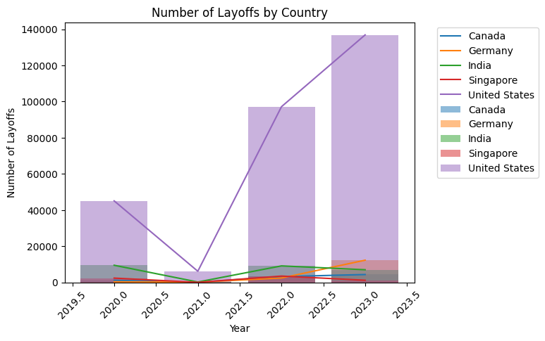

```python
# Convert the data frame to a dictionary with Year and Country as keys
layoff_dict = layoff_final_df.to_dict(orient="index")

# Convert the dictionary values to lists
for key, value in layoff_dict.items():
    value["Year"] = list(value.keys())
    value["Layoffs"] = list(value.values())
    del value["Year"]
    del value["Layoffs"]
layoff_dict

# Pivot the data frame
layoff_final_df = layoff_counts_df.pivot(
    index="Country", columns="Year", values="Total Layoffs").dropna()

# Convert the data frame to a dictionary with Year and Country as keys
layoff_dict = layoff_final_df.to_dict(orient="index")

# Convert the dictionary values to lists
layoff_final_df = {"Year": list(layoff_dict.values())[0].keys()}
for key, value in layoff_dict.items():
    layoff_final_df[key] = list(value.values())
layoff_final_df = pd.DataFrame(layoff_final_df)

# Set the index to ‘Year’
layoff_final_df.set_index("Year", inplace=True)

# Create a figure and axis object
fig, ax = plt.subplots()

# Plot the histograms
for country in layoff_final_df.columns:
    ax.bar(layoff_final_df.index,
           layoff_final_df[country], label=country, alpha=0.5)

# Plot the line graphs
for country in layoff_final_df.columns:
    ax.plot(layoff_final_df.index, layoff_final_df[country], label=country)
ax.set_xlabel("Year")
ax.set_ylabel("Number of Layoffs")
ax.set_title("Number of Layoffs by Country")
ax.legend(bbox_to_anchor=(1.05, 1), loc="upper left")
plt.xticks(rotation=45)
plt.show()
```

**Interpretation:**

By combining both bar plots and line graphs, we can discern significant patterns and variations in the number of layoffs. The bar plots provide a comparative analysis, showcasing the disparities in layoffs between different countries for each year; for example, United States ranking extremely highly. On the other hand, the line graphs depict the temporal evolution of layoffs, allowing us to observe trends and fluctuations in each country's labor market. Interestingly, while some countries exhibit relatively stable layoff rates over the years, others display notable fluctuations, suggesting potential economic or political factors at play. Overall, this visualization serves as a comprehensive tool for policymakers and analysts to identify regions of stability, emerging challenges, and opportunities for intervention in the global labor market landscape.

## World Income Groups Dataset

```python
# Read in the data
income_df = pd.read_csv('income_groups.csv')
income_df
```

|  | country_code | region | income_group |
| --- | --- | --- | --- |
| 0 | ABW | Latin America & Caribbean | High income |
| 1 | AFG | South Asia | Low income |
| 2 | AGO | Sub-Saharan Africa | Lower middle income |
| 3 | ALB | Europe & Central Asia | Upper middle income |
| 4 | AND | Europe & Central Asia | High income |
| ... | ... | ... | ... |
| 212 | XKX | Europe & Central Asia | Upper middle income |
| 213 | YEM | Middle East & North Africa | Low income |
| 214 | ZAF | Sub-Saharan Africa | Upper middle income |
| 215 | ZMB | Sub-Saharan Africa | Lower middle income |
| 216 | ZWE | Sub-Saharan Africa | Lower middle income |

217 rows × 3 columns

```python
# Pip install the pycountry library
!pip install pycountry
```

```python
def country_code_to_name(country_code):
    '''Converts a country code to a country name'''
    # Use the pycountry library to convert the country code to a country name
    try:
        country = pycountry.countries.get(
            alpha_3=country_code)  # Get the country name
        return country.name
    except AttributeError:
        return "Unknown"
```

```python
# Apply the function to the 'country_code' column
income_df['Country'] = income_df['country_code'].apply(country_code_to_name)
income_df
```

|  | country_code | region | income_group | Country |
| --- | --- | --- | --- | --- |
| 0 | ABW | Latin America & Caribbean | High income | Aruba |
| 1 | AFG | South Asia | Low income | Afghanistan |
| 2 | AGO | Sub-Saharan Africa | Lower middle income | Angola |
| 3 | ALB | Europe & Central Asia | Upper middle income | Albania |
| 4 | AND | Europe & Central Asia | High income | Andorra |
| ... | ... | ... | ... | ... |
| 212 | XKX | Europe & Central Asia | Upper middle income | Unknown |
| 213 | YEM | Middle East & North Africa | Low income | Yemen |
| 214 | ZAF | Sub-Saharan Africa | Upper middle income | South Africa |
| 215 | ZMB | Sub-Saharan Africa | Lower middle income | Zambia |
| 216 | ZWE | Sub-Saharan Africa | Lower middle income | Zimbabwe |

217 rows × 4 columns

```python
# Drop missing values
income_df.dropna(inplace=True)
income_df
```

|  | country_code | region | income_group | Country |
| --- | --- | --- | --- | --- |
| 0 | ABW | Latin America & Caribbean | High income | Aruba |
| 1 | AFG | South Asia | Low income | Afghanistan |
| 2 | AGO | Sub-Saharan Africa | Lower middle income | Angola |
| 3 | ALB | Europe & Central Asia | Upper middle income | Albania |
| 4 | AND | Europe & Central Asia | High income | Andorra |
| ... | ... | ... | ... | ... |
| 212 | XKX | Europe & Central Asia | Upper middle income | Unknown |
| 213 | YEM | Middle East & North Africa | Low income | Yemen |
| 214 | ZAF | Sub-Saharan Africa | Upper middle income | South Africa |
| 215 | ZMB | Sub-Saharan Africa | Lower middle income | Zambia |
| 216 | ZWE | Sub-Saharan Africa | Lower middle income | Zimbabwe |

217 rows × 4 columns

```python
# Find the "Unknown" values to replace with the correct country names
unknown_vales = income_df[income_df['Country'] == 'Unknown']
unknown_vales
```

|  | country_code | region | income_group | Country |
| --- | --- | --- | --- | --- |
| 34 | CHI | Europe & Central Asia | High income | Unknown |
| 212 | XKX | Europe & Central Asia | Upper middle income | Unknown |

```python
# Replace "Unknown" values in the "Country" column based on different conditions
income_df.loc[(income_df['Country'] == 'Unknown') & (
    income_df['income_group'] == 'Upper middle income'), 'Country'] = 'Kosovo'
income_df.loc[(income_df['Country'] == 'Unknown') & (
    income_df['income_group'] == 'High income'), 'Country'] = 'Czech Republic,'
income_df
```

|  | country_code | region | income_group | Country |
| --- | --- | --- | --- | --- |
| 0 | ABW | Latin America & Caribbean | High income | Aruba |
| 1 | AFG | South Asia | Low income | Afghanistan |
| 2 | AGO | Sub-Saharan Africa | Lower middle income | Angola |
| 3 | ALB | Europe & Central Asia | Upper middle income | Albania |
| 4 | AND | Europe & Central Asia | High income | Andorra |
| ... | ... | ... | ... | ... |
| 212 | XKX | Europe & Central Asia | Upper middle income | Kosovo |
| 213 | YEM | Middle East & North Africa | Low income | Yemen |
| 214 | ZAF | Sub-Saharan Africa | Upper middle income | South Africa |
| 215 | ZMB | Sub-Saharan Africa | Lower middle income | Zambia |
| 216 | ZWE | Sub-Saharan Africa | Lower middle income | Zimbabwe |

217 rows × 4 columns

```python
# Drop the "country_code" and "region" columns
income_df.drop(columns=['country_code', 'region'], inplace=True)
income_df
```

|  | income_group | Country |
| --- | --- | --- |
| 0 | High income | Aruba |
| 1 | Low income | Afghanistan |
| 2 | Lower middle income | Angola |
| 3 | Upper middle income | Albania |
| 4 | High income | Andorra |
| ... | ... | ... |
| 212 | Upper middle income | Kosovo |
| 213 | Low income | Yemen |
| 214 | Upper middle income | South Africa |
| 215 | Lower middle income | Zambia |
| 216 | Lower middle income | Zimbabwe |

217 rows × 2 columns

```python
# Make a copy of the data frame
income_final_df = income_df.copy()

# Rename the columns to be more descriptive and consistent
income_final_df.rename(
    columns={'Country': 'Country', 'income_group': 'Income Group'}, inplace=True)

# Reindex the columns
income_final_df = income_final_df.reindex(columns=['Country', 'Income Group'])
income_final_df
```

|  | Country | Income Group |
| --- | --- | --- |
| 0 | Aruba | High income |
| 1 | Afghanistan | Low income |
| 2 | Angola | Lower middle income |
| 3 | Albania | Upper middle income |
| 4 | Andorra | High income |
| ... | ... | ... |
| 212 | Kosovo | Upper middle income |
| 213 | Yemen | Low income |
| 214 | South Africa | Upper middle income |
| 215 | Zambia | Lower middle income |
| 216 | Zimbabwe | Lower middle income |

217 rows × 2 columns

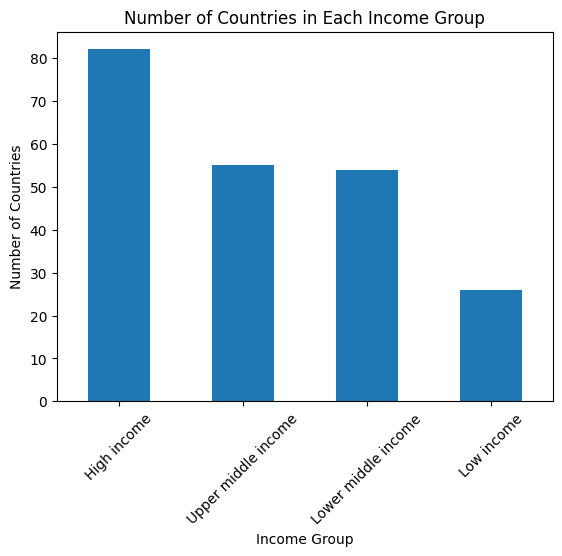

```python
# Visualize the income group data in a digestible format
income_final_df['Income Group'].value_counts().plot(kind='bar')
plt.title('Number of Countries in Each Income Group')
plt.xlabel('Income Group')
plt.ylabel('Number of Countries')
plt.xticks(rotation=45)
plt.show()
```

# Global GDP Growth Rate Dataset

```python
# Read in the data
gdpgrowth_df = pd.read_csv('gdp_growth_rate.csv')
gdpgrowth_df
```

|  | Real GDP growth (Annual percent change) | 1980 | 1981 | 1982 | 1983 | 1984 | 1985 | 1986 | 1987 | 1988 | ... | 2019 | 2020 | 2021 | 2022 | 2023 | 2024 | 2025 | 2026 | 2027 | 2028 |
| --- | --- | --- | --- | --- | --- | --- | --- | --- | --- | --- | --- | --- | --- | --- | --- | --- | --- | --- | --- | --- | --- |
| 0 | NaN | NaN | NaN | NaN | NaN | NaN | NaN | NaN | NaN | NaN | ... | NaN | NaN | NaN | NaN | NaN | NaN | NaN | NaN | NaN | NaN |
| 1 | Afghanistan | no data | no data | no data | no data | no data | no data | no data | no data | no data | ... | 3.9 | -2.4 | -20.7 | no data | no data | no data | no data | no data | no data | no data |
| 2 | Albania | 2.7 | 5.7 | 2.9 | 1.1 | 2 | -1.5 | 5.6 | -0.8 | -1.4 | ... | 2.1 | -3.3 | 8.9 | 4.8 | 3.6 | 3.3 | 3.4 | 3.5 | 3.5 | 3.5 |
| 3 | Algeria | -5.4 | 3 | 6.4 | 5.4 | 5.6 | 5.6 | -0.2 | -0.7 | -1.9 | ... | 1 | -5.1 | 3.4 | 3.2 | 3.8 | 3.1 | 2.5 | 1.9 | 1.7 | 1.7 |
| 4 | Andorra | no data | no data | no data | no data | no data | no data | no data | no data | no data | ... | 2 | -11.2 | 8.3 | 8.8 | 2.1 | 1.5 | 1.5 | 1.5 | 1.5 | 1.5 |
| ... | ... | ... | ... | ... | ... | ... | ... | ... | ... | ... | ... | ... | ... | ... | ... | ... | ... | ... | ... | ... | ... |
| 226 | Other advanced economies | 3.8 | 4.2 | 2.1 | 4 | 6.6 | 4.3 | 5.5 | 6.5 | 5.5 | ... | 2 | -1.6 | 5.7 | 2.6 | 1.8 | 2.2 | 2.3 | 2.3 | 2.2 | 2.2 |
| 227 | Sub-Saharan Africa | no data | no data | no data | no data | no data | no data | no data | no data | no data | ... | 3.2 | -1.6 | 4.7 | 4 | 3.3 | 4 | 4.1 | 4.1 | 4.2 | 4.3 |
| 228 | World | 2.2 | 2.1 | 0.7 | 2.6 | 4.6 | 3.6 | 3.6 | 3.9 | 4.7 | ... | 2.8 | -2.8 | 6.3 | 3.5 | 3 | 2.9 | 3.2 | 3.2 | 3.1 | 3.1 |
| 229 | NaN | NaN | NaN | NaN | NaN | NaN | NaN | NaN | NaN | NaN | ... | NaN | NaN | NaN | NaN | NaN | NaN | NaN | NaN | NaN | NaN |
| 230 | ©IMF, 2023 | NaN | NaN | NaN | NaN | NaN | NaN | NaN | NaN | NaN | ... | NaN | NaN | NaN | NaN | NaN | NaN | NaN | NaN | NaN | NaN |

231 rows × 50 columns

```python
# Find missing values
gdpgrowth_df.info()
```

```
<class 'pandas.core.frame.DataFrame'>
RangeIndex: 231 entries, 0 to 230
Data columns (total 50 columns):
 #   Column                                   Non-Null Count  Dtype
---  ------                                   --------------  -----
 0   Real GDP growth (Annual percent change)  229 non-null    object
 1   1980                                     228 non-null    object
 2   1981                                     228 non-null    object
 3   1982                                     228 non-null    object
 4   1983                                     228 non-null    object
 5   1984                                     228 non-null    object
 6   1985                                     228 non-null    object
 7   1986                                     228 non-null    object
 8   1987                                     228 non-null    object
 9   1988                                     228 non-null    object
```

[output cut: 42 more lines]

```python
# Select the columns we want to keep
gdpgrowth_recent = gdpgrowth_df[[
    "Real GDP growth (Annual percent change)", "2020", "2021", "2022", "2023"]]

# Drop missing values
gdpgrowth_recent = gdpgrowth_recent.dropna()
gdpgrowth_recent
```

|  | Real GDP growth (Annual percent change) | 2020 | 2021 | 2022 | 2023 |
| --- | --- | --- | --- | --- | --- |
| 1 | Afghanistan | -2.4 | -20.7 | no data | no data |
| 2 | Albania | -3.3 | 8.9 | 4.8 | 3.6 |
| 3 | Algeria | -5.1 | 3.4 | 3.2 | 3.8 |
| 4 | Andorra | -11.2 | 8.3 | 8.8 | 2.1 |
| 5 | Angola | -5.6 | 1.2 | 3 | 1.3 |
| ... | ... | ... | ... | ... | ... |
| 224 | Major advanced economies (G7) | -4.5 | 5.4 | 2.3 | 1.5 |
| 225 | Middle East and Central Asia | -2.6 | 4.3 | 5.6 | 2 |
| 226 | Other advanced economies | -1.6 | 5.7 | 2.6 | 1.8 |
| 227 | Sub-Saharan Africa | -1.6 | 4.7 | 4 | 3.3 |
| 228 | World | -2.8 | 6.3 | 3.5 | 3 |

228 rows × 5 columns

```python
# Replace "no data" with pd.NA
gdpgrowth_recent.replace("no data", pd.NA, inplace=True)
gdpgrowth_recent
```

|  | Real GDP growth (Annual percent change) | 2020 | 2021 | 2022 | 2023 |
| --- | --- | --- | --- | --- | --- |
| 1 | Afghanistan | -2.4 | -20.7 | <NA> | <NA> |
| 2 | Albania | -3.3 | 8.9 | 4.8 | 3.6 |
| 3 | Algeria | -5.1 | 3.4 | 3.2 | 3.8 |
| 4 | Andorra | -11.2 | 8.3 | 8.8 | 2.1 |
| 5 | Angola | -5.6 | 1.2 | 3 | 1.3 |
| ... | ... | ... | ... | ... | ... |
| 224 | Major advanced economies (G7) | -4.5 | 5.4 | 2.3 | 1.5 |
| 225 | Middle East and Central Asia | -2.6 | 4.3 | 5.6 | 2 |
| 226 | Other advanced economies | -1.6 | 5.7 | 2.6 | 1.8 |
| 227 | Sub-Saharan Africa | -1.6 | 4.7 | 4 | 3.3 |
| 228 | World | -2.8 | 6.3 | 3.5 | 3 |

228 rows × 5 columns

```python
# Make a copy of the data frame
gdpgrowth_country_final_df = gdpgrowth_recent.copy()

# Rename the columns to be more descriptive and consistent
gdpgrowth_country_final_df.rename(columns={"Real GDP growth (Annual percent change)": "Country", "2020": "Annual GDP Growth(2020)", "2021": "Annual GDP Growth(2021)",
                                           "2022": "Annual GDP Growth(2022)", "2023": "Annual GDP Growth(2023)"}, inplace=True)

# Reset the index
gdpgrowth_country_final_df.reset_index(drop=True, inplace=True)

# Select the rows from 1 to 195
gdpgrowth_country_final_df = gdpgrowth_country_final_df.iloc[1:195].copy()
gdpgrowth_country_final_df
```

|  | Country | Annual GDP Growth(2020) | Annual GDP Growth(2021) | Annual GDP Growth(2022) | Annual GDP Growth(2023) |
| --- | --- | --- | --- | --- | --- |
| 1 | Albania | -3.3 | 8.9 | 4.8 | 3.6 |
| 2 | Algeria | -5.1 | 3.4 | 3.2 | 3.8 |
| 3 | Andorra | -11.2 | 8.3 | 8.8 | 2.1 |
| 4 | Angola | -5.6 | 1.2 | 3 | 1.3 |
| 5 | Antigua and Barbuda | -17.5 | 6.6 | 8.5 | 5.6 |
| ... | ... | ... | ... | ... | ... |
| 190 | Venezuela | -30 | 1 | 8 | 4 |
| 191 | Vietnam | 2.9 | 2.6 | 8 | 4.7 |
| 192 | West Bank and Gaza | -11.3 | 7 | 3.9 | 3 |
| 193 | Yemen | -8.5 | -1 | 1.5 | -0.5 |
| 194 | Zambia | -2.8 | 4.6 | 4.7 | 3.6 |

194 rows × 5 columns

[figure not shown]

```python
# Convert the columns to numeric data types
gdpgrowth_country_final_df['Annual GDP Growth(2020)'] = pd.to_numeric(
    gdpgrowth_country_final_df['Annual GDP Growth(2020)'])
gdpgrowth_country_final_df['Annual GDP Growth(2021)'] = pd.to_numeric(
    gdpgrowth_country_final_df['Annual GDP Growth(2021)'])
gdpgrowth_country_final_df['Annual GDP Growth(2022)'] = pd.to_numeric(
    gdpgrowth_country_final_df['Annual GDP Growth(2022)'])
gdpgrowth_country_final_df['Annual GDP Growth(2023)'] = pd.to_numeric(
    gdpgrowth_country_final_df['Annual GDP Growth(2023)'])

# Sort the dataframe by each year's GDP growth rate in descending order
gdpgrowth_sorted = gdpgrowth_country_final_df.sort_values(
    by=['Annual GDP Growth(2020)', 'Annual GDP Growth(2021)', 'Annual GDP Growth(2022)', 'Annual GDP Growth(2023)'], ascending=False)

# Get the top ten countries with the highest GDP growth rate for each year
top_ten_2020 = gdpgrowth_sorted.head(10)['Country']
top_ten_2021 = gdpgrowth_sorted.head(10)['Country']
top_ten_2022 = gdpgrowth_sorted.head(10)['Country']
top_ten_2023 = gdpgrowth_sorted.head(10)['Country']

# Visualize the top ten countries with the highest GDP growth rate for each year
fig, axes = plt.subplots(nrows=2, ncols=2, figsize=(12, 8))

# Plot for 2020
axes[0, 0].bar(top_ten_2020, gdpgrowth_sorted.head(10)
               ['Annual GDP Growth(2020)'])
axes[0, 0].set_xlabel('Country')
axes[0, 0].set_ylabel('GDP Growth Rate')
axes[0, 0].set_title('Top Ten Countries with Highest GDP Growth Rate in 2020')
axes[0, 0].tick_params(axis='x', rotation=45)

# Plot for 2021
axes[0, 1].bar(top_ten_2021, gdpgrowth_sorted.head(10)
               ['Annual GDP Growth(2021)'])
axes[0, 1].set_xlabel('Country')
axes[0, 1].set_ylabel('GDP Growth Rate')
axes[0, 1].set_title('Top Ten Countries with Highest GDP Growth Rate in 2021')
axes[0, 1].tick_params(axis='x', rotation=45)

# Plot for 2022
axes[1, 0].bar(top_ten_2022, gdpgrowth_sorted.head(10)
               ['Annual GDP Growth(2022)'])
axes[1, 0].set_xlabel('Country')
axes[1, 0].set_ylabel('GDP Growth Rate')
axes[1, 0].set_title('Top Ten Countries with Highest GDP Growth Rate in 2022')
axes[1, 0].tick_params(axis='x', rotation=45)

# Plot for 2023
axes[1, 1].bar(top_ten_2023, gdpgrowth_sorted.head(10)
               ['Annual GDP Growth(2023)'])
axes[1, 1].set_xlabel('Country')
axes[1, 1].set_ylabel('GDP Growth Rate')
axes[1, 1].set_title('Top Ten Countries with Highest GDP Growth Rate in 2023')
axes[1, 1].tick_params(axis='x', rotation=45)

# Adjust the layout
plt.tight_layout()
plt.show()
```

# World Happiness Reports

### Happiness Dataset - 2020

```python
# Read in the data
happiness2020_df = pd.read_csv('world_happiness_report_2020.csv')
happiness2020_df
```

|  | Country name | Regional indicator | Ladder score | Standard error of ladder score | upperwhisker | lowerwhisker | Logged GDP per capita | Social support | Healthy life expectancy | Freedom to make life choices | Generosity | Perceptions of corruption | Ladder score in Dystopia | Explained by: Log GDP per capita | Explained by: Social support | Explained by: Healthy life expectancy | Explained by: Freedom to make life choices | Explained by: Generosity | Explained by: Perceptions of corruption | Dystopia + residual |
| --- | --- | --- | --- | --- | --- | --- | --- | --- | --- | --- | --- | --- | --- | --- | --- | --- | --- | --- | --- | --- |
| 0 | Finland | Western Europe | 7.8087 | 0.031156 | 7.869766 | 7.747634 | 10.639267 | 0.954330 | 71.900825 | 0.949172 | -0.059482 | 0.195445 | 1.972317 | 1.285190 | 1.499526 | 0.961271 | 0.662317 | 0.159670 | 0.477857 | 2.762835 |
| 1 | Denmark | Western Europe | 7.6456 | 0.033492 | 7.711245 | 7.579955 | 10.774001 | 0.955991 | 72.402504 | 0.951444 | 0.066202 | 0.168489 | 1.972317 | 1.326949 | 1.503449 | 0.979333 | 0.665040 | 0.242793 | 0.495260 | 2.432741 |
| 2 | Switzerland | Western Europe | 7.5599 | 0.035014 | 7.628528 | 7.491272 | 10.979933 | 0.942847 | 74.102448 | 0.921337 | 0.105911 | 0.303728 | 1.972317 | 1.390774 | 1.472403 | 1.040533 | 0.628954 | 0.269056 | 0.407946 | 2.350267 |
| 3 | Iceland | Western Europe | 7.5045 | 0.059616 | 7.621347 | 7.387653 | 10.772559 | 0.974670 | 73.000000 | 0.948892 | 0.246944 | 0.711710 | 1.972317 | 1.326502 | 1.547567 | 1.000843 | 0.661981 | 0.362330 | 0.144541 | 2.460688 |
| 4 | Norway | Western Europe | 7.4880 | 0.034837 | 7.556281 | 7.419719 | 11.087804 | 0.952487 | 73.200783 | 0.955750 | 0.134533 | 0.263218 | 1.972317 | 1.424207 | 1.495173 | 1.008072 | 0.670201 | 0.287985 | 0.434101 | 2.168266 |
| ... | ... | ... | ... | ... | ... | ... | ... | ... | ... | ... | ... | ... | ... | ... | ... | ... | ... | ... | ... | ... |
| 148 | Central African Republic | Sub-Saharan Africa | 3.4759 | 0.115183 | 3.701658 | 3.250141 | 6.625160 | 0.319460 | 45.200001 | 0.640881 | 0.082410 | 0.891807 | 1.972317 | 0.041072 | 0.000000 | 0.000000 | 0.292814 | 0.253513 | 0.028265 | 2.860198 |
| 149 | Rwanda | Sub-Saharan Africa | 3.3123 | 0.052425 | 3.415053 | 3.209547 | 7.600104 | 0.540835 | 61.098846 | 0.900589 | 0.055484 | 0.183541 | 1.972317 | 0.343243 | 0.522876 | 0.572383 | 0.604088 | 0.235705 | 0.485542 | 0.548445 |
| 150 | Zimbabwe | Sub-Saharan Africa | 3.2992 | 0.058674 | 3.414202 | 3.184198 | 7.865712 | 0.763093 | 55.617260 | 0.711458 | -0.072064 | 0.810237 | 1.972317 | 0.425564 | 1.047835 | 0.375038 | 0.377405 | 0.151349 | 0.080929 | 0.841031 |
| 151 | South Sudan | Sub-Saharan Africa | 2.8166 | 0.107610 | 3.027516 | 2.605684 | 7.425360 | 0.553707 | 51.000000 | 0.451314 | 0.016519 | 0.763417 | 1.972317 | 0.289083 | 0.553279 | 0.208809 | 0.065609 | 0.209935 | 0.111157 | 1.378751 |
| 152 | Afghanistan | South Asia | 2.5669 | 0.031311 | 2.628270 | 2.505530 | 7.462861 | 0.470367 | 52.590000 | 0.396573 | -0.096429 | 0.933687 | 1.972317 | 0.300706 | 0.356434 | 0.266052 | 0.000000 | 0.135235 | 0.001226 | 1.507236 |

153 rows × 20 columns

```python
# Select the columns we want to keep
happiness2020_refined_df = happiness2020_df[["Country name", "Regional indicator", "Ladder score", "Logged GDP per capita", "Social support",
                                             "Healthy life expectancy", "Freedom to make life choices", "Perceptions of corruption"]]
happiness2020_refined_df
```

|  | Country name | Regional indicator | Ladder score | Logged GDP per capita | Social support | Healthy life expectancy | Freedom to make life choices | Perceptions of corruption |
| --- | --- | --- | --- | --- | --- | --- | --- | --- |
| 0 | Finland | Western Europe | 7.8087 | 10.639267 | 0.954330 | 71.900825 | 0.949172 | 0.195445 |
| 1 | Denmark | Western Europe | 7.6456 | 10.774001 | 0.955991 | 72.402504 | 0.951444 | 0.168489 |
| 2 | Switzerland | Western Europe | 7.5599 | 10.979933 | 0.942847 | 74.102448 | 0.921337 | 0.303728 |
| 3 | Iceland | Western Europe | 7.5045 | 10.772559 | 0.974670 | 73.000000 | 0.948892 | 0.711710 |
| 4 | Norway | Western Europe | 7.4880 | 11.087804 | 0.952487 | 73.200783 | 0.955750 | 0.263218 |
| ... | ... | ... | ... | ... | ... | ... | ... | ... |
| 148 | Central African Republic | Sub-Saharan Africa | 3.4759 | 6.625160 | 0.319460 | 45.200001 | 0.640881 | 0.891807 |
| 149 | Rwanda | Sub-Saharan Africa | 3.3123 | 7.600104 | 0.540835 | 61.098846 | 0.900589 | 0.183541 |
| 150 | Zimbabwe | Sub-Saharan Africa | 3.2992 | 7.865712 | 0.763093 | 55.617260 | 0.711458 | 0.810237 |
| 151 | South Sudan | Sub-Saharan Africa | 2.8166 | 7.425360 | 0.553707 | 51.000000 | 0.451314 | 0.763417 |
| 152 | Afghanistan | South Asia | 2.5669 | 7.462861 | 0.470367 | 52.590000 | 0.396573 | 0.933687 |

153 rows × 8 columns

```python
# Make a copy of the data frame
happiness2020_final_df = happiness2020_refined_df.copy()

# Drop missing values
happiness2020_final_df.dropna(inplace=True)
```

```python
# Rename the columns to be more descriptive and consistent
happiness2020_final_df.rename(columns={"Country name": "Country", "Regional indicator": "Region", "Ladder score": "Happiness Score(2020)", "Logged GDP per capita": "GDP per Capita(2020)", "Social support": "Social Support(2020)",
                                       "Healthy life expectancy": "Life Expectancy(2020)", "Freedom to make life choices": "Freedom(2020)", "Perceptions of corruption": "Corruption(2020)"}, inplace=True)
happiness2020_final_df
```

|  | Country | Region | Happiness Score(2020) | GDP per Capita(2020) | Social Support(2020) | Life Expectancy(2020) | Freedom(2020) | Corruption(2020) |
| --- | --- | --- | --- | --- | --- | --- | --- | --- |
| 0 | Finland | Western Europe | 7.8087 | 10.639267 | 0.954330 | 71.900825 | 0.949172 | 0.195445 |
| 1 | Denmark | Western Europe | 7.6456 | 10.774001 | 0.955991 | 72.402504 | 0.951444 | 0.168489 |
| 2 | Switzerland | Western Europe | 7.5599 | 10.979933 | 0.942847 | 74.102448 | 0.921337 | 0.303728 |
| 3 | Iceland | Western Europe | 7.5045 | 10.772559 | 0.974670 | 73.000000 | 0.948892 | 0.711710 |
| 4 | Norway | Western Europe | 7.4880 | 11.087804 | 0.952487 | 73.200783 | 0.955750 | 0.263218 |
| ... | ... | ... | ... | ... | ... | ... | ... | ... |
| 148 | Central African Republic | Sub-Saharan Africa | 3.4759 | 6.625160 | 0.319460 | 45.200001 | 0.640881 | 0.891807 |
| 149 | Rwanda | Sub-Saharan Africa | 3.3123 | 7.600104 | 0.540835 | 61.098846 | 0.900589 | 0.183541 |
| 150 | Zimbabwe | Sub-Saharan Africa | 3.2992 | 7.865712 | 0.763093 | 55.617260 | 0.711458 | 0.810237 |
| 151 | South Sudan | Sub-Saharan Africa | 2.8166 | 7.425360 | 0.553707 | 51.000000 | 0.451314 | 0.763417 |
| 152 | Afghanistan | South Asia | 2.5669 | 7.462861 | 0.470367 | 52.590000 | 0.396573 | 0.933687 |

153 rows × 8 columns

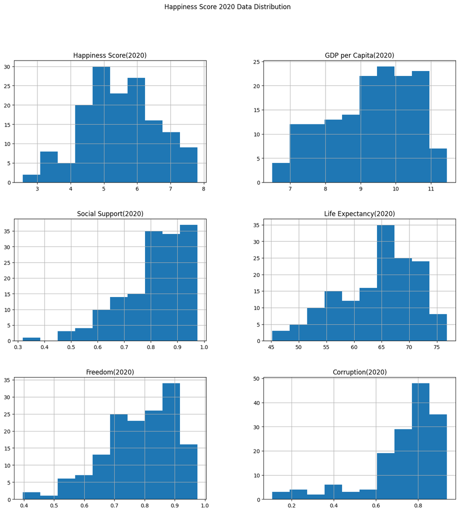

```python
# Visualize the happiness score 2020 data against all the other columns
happiness2020_final_df.hist(figsize=(15, 15))
plt.suptitle("Happiness Score 2020 Data Distribution")
plt.show()
```

**Interpretation:**

The histogram visualization above provides a succinct overview of the distribution of data for the Happiness Score in the year 2020 across various other columns in the dataset. Each subplot represents a different column, displaying the frequency distribution of values within that column. Notably, a common trend emerges where all variables tend to be skewed towards the right side of the histogram, indicating a concentration of higher values. This concise visualization aids in quickly understanding the spread and central tendencies of the dataset, facilitating the identification of any notable patterns or outliers. Such insights are essential for informing subsequent analysis and decision-making processes, making this visualization a valuable exploratory tool in data analysis workflows.

### Happiness Dataset - 2021

```python
# Read in the data
happiness2021_df = pd.read_csv('world_happiness_report_2021.csv')
happiness2021_df
```

|  | Country name | Regional indicator | Ladder score | Standard error of ladder score | upperwhisker | lowerwhisker | Logged GDP per capita | Social support | Healthy life expectancy | Freedom to make life choices | Generosity | Perceptions of corruption | Ladder score in Dystopia | Explained by: Log GDP per capita | Explained by: Social support | Explained by: Healthy life expectancy | Explained by: Freedom to make life choices | Explained by: Generosity | Explained by: Perceptions of corruption | Dystopia + residual |
| --- | --- | --- | --- | --- | --- | --- | --- | --- | --- | --- | --- | --- | --- | --- | --- | --- | --- | --- | --- | --- |
| 0 | Finland | Western Europe | 7.842 | 0.032 | 7.904 | 7.780 | 10.775 | 0.954 | 72.000 | 0.949 | -0.098 | 0.186 | 2.43 | 1.446 | 1.106 | 0.741 | 0.691 | 0.124 | 0.481 | 3.253 |
| 1 | Denmark | Western Europe | 7.620 | 0.035 | 7.687 | 7.552 | 10.933 | 0.954 | 72.700 | 0.946 | 0.030 | 0.179 | 2.43 | 1.502 | 1.108 | 0.763 | 0.686 | 0.208 | 0.485 | 2.868 |
| 2 | Switzerland | Western Europe | 7.571 | 0.036 | 7.643 | 7.500 | 11.117 | 0.942 | 74.400 | 0.919 | 0.025 | 0.292 | 2.43 | 1.566 | 1.079 | 0.816 | 0.653 | 0.204 | 0.413 | 2.839 |
| 3 | Iceland | Western Europe | 7.554 | 0.059 | 7.670 | 7.438 | 10.878 | 0.983 | 73.000 | 0.955 | 0.160 | 0.673 | 2.43 | 1.482 | 1.172 | 0.772 | 0.698 | 0.293 | 0.170 | 2.967 |
| 4 | Netherlands | Western Europe | 7.464 | 0.027 | 7.518 | 7.410 | 10.932 | 0.942 | 72.400 | 0.913 | 0.175 | 0.338 | 2.43 | 1.501 | 1.079 | 0.753 | 0.647 | 0.302 | 0.384 | 2.798 |
| ... | ... | ... | ... | ... | ... | ... | ... | ... | ... | ... | ... | ... | ... | ... | ... | ... | ... | ... | ... | ... |
| 144 | Lesotho | Sub-Saharan Africa | 3.512 | 0.120 | 3.748 | 3.276 | 7.926 | 0.787 | 48.700 | 0.715 | -0.131 | 0.915 | 2.43 | 0.451 | 0.731 | 0.007 | 0.405 | 0.103 | 0.015 | 1.800 |
| 145 | Botswana | Sub-Saharan Africa | 3.467 | 0.074 | 3.611 | 3.322 | 9.782 | 0.784 | 59.269 | 0.824 | -0.246 | 0.801 | 2.43 | 1.099 | 0.724 | 0.340 | 0.539 | 0.027 | 0.088 | 0.648 |
| 146 | Rwanda | Sub-Saharan Africa | 3.415 | 0.068 | 3.548 | 3.282 | 7.676 | 0.552 | 61.400 | 0.897 | 0.061 | 0.167 | 2.43 | 0.364 | 0.202 | 0.407 | 0.627 | 0.227 | 0.493 | 1.095 |
| 147 | Zimbabwe | Sub-Saharan Africa | 3.145 | 0.058 | 3.259 | 3.030 | 7.943 | 0.750 | 56.201 | 0.677 | -0.047 | 0.821 | 2.43 | 0.457 | 0.649 | 0.243 | 0.359 | 0.157 | 0.075 | 1.205 |
| 148 | Afghanistan | South Asia | 2.523 | 0.038 | 2.596 | 2.449 | 7.695 | 0.463 | 52.493 | 0.382 | -0.102 | 0.924 | 2.43 | 0.370 | 0.000 | 0.126 | 0.000 | 0.122 | 0.010 | 1.895 |

149 rows × 20 columns

```python
# Select the columns we want to keep
happiness2021_refined_df = happiness2021_df[["Country name", "Regional indicator", "Ladder score", "Logged GDP per capita", "Social support",
                                             "Healthy life expectancy", "Freedom to make life choices", "Perceptions of corruption"]]
happiness2021_refined_df
```

|  | Country name | Regional indicator | Ladder score | Logged GDP per capita | Social support | Healthy life expectancy | Freedom to make life choices | Perceptions of corruption |
| --- | --- | --- | --- | --- | --- | --- | --- | --- |
| 0 | Finland | Western Europe | 7.842 | 10.775 | 0.954 | 72.000 | 0.949 | 0.186 |
| 1 | Denmark | Western Europe | 7.620 | 10.933 | 0.954 | 72.700 | 0.946 | 0.179 |
| 2 | Switzerland | Western Europe | 7.571 | 11.117 | 0.942 | 74.400 | 0.919 | 0.292 |
| 3 | Iceland | Western Europe | 7.554 | 10.878 | 0.983 | 73.000 | 0.955 | 0.673 |
| 4 | Netherlands | Western Europe | 7.464 | 10.932 | 0.942 | 72.400 | 0.913 | 0.338 |
| ... | ... | ... | ... | ... | ... | ... | ... | ... |
| 144 | Lesotho | Sub-Saharan Africa | 3.512 | 7.926 | 0.787 | 48.700 | 0.715 | 0.915 |
| 145 | Botswana | Sub-Saharan Africa | 3.467 | 9.782 | 0.784 | 59.269 | 0.824 | 0.801 |
| 146 | Rwanda | Sub-Saharan Africa | 3.415 | 7.676 | 0.552 | 61.400 | 0.897 | 0.167 |
| 147 | Zimbabwe | Sub-Saharan Africa | 3.145 | 7.943 | 0.750 | 56.201 | 0.677 | 0.821 |
| 148 | Afghanistan | South Asia | 2.523 | 7.695 | 0.463 | 52.493 | 0.382 | 0.924 |

149 rows × 8 columns

```python
# Make a copy of the data frame
happiness2021_final_df = happiness2021_refined_df.copy()

# Drop missing values
happiness2021_final_df.dropna(inplace=True)
```

```python
# Rename the columns to be more descriptive and consistent
happiness2021_final_df.rename(columns={"Country name": "Country", "Regional indicator": "Region", "Ladder score": "Happiness Score(2021)", "Logged GDP per capita": "GDP per Capita(2021)", "Social support": "Social Support(2021)",
                                       "Healthy life expectancy": "Life Expectancy(2021)", "Freedom to make life choices": "Freedom(2021)", "Perceptions of corruption": "Corruption(2021)"}, inplace=True)
happiness2021_final_df
```

|  | Country | Region | Happiness Score(2021) | GDP per Capita(2021) | Social Support(2021) | Life Expectancy(2021) | Freedom(2021) | Corruption(2021) |
| --- | --- | --- | --- | --- | --- | --- | --- | --- |
| 0 | Finland | Western Europe | 7.842 | 10.775 | 0.954 | 72.000 | 0.949 | 0.186 |
| 1 | Denmark | Western Europe | 7.620 | 10.933 | 0.954 | 72.700 | 0.946 | 0.179 |
| 2 | Switzerland | Western Europe | 7.571 | 11.117 | 0.942 | 74.400 | 0.919 | 0.292 |
| 3 | Iceland | Western Europe | 7.554 | 10.878 | 0.983 | 73.000 | 0.955 | 0.673 |
| 4 | Netherlands | Western Europe | 7.464 | 10.932 | 0.942 | 72.400 | 0.913 | 0.338 |
| ... | ... | ... | ... | ... | ... | ... | ... | ... |
| 144 | Lesotho | Sub-Saharan Africa | 3.512 | 7.926 | 0.787 | 48.700 | 0.715 | 0.915 |
| 145 | Botswana | Sub-Saharan Africa | 3.467 | 9.782 | 0.784 | 59.269 | 0.824 | 0.801 |
| 146 | Rwanda | Sub-Saharan Africa | 3.415 | 7.676 | 0.552 | 61.400 | 0.897 | 0.167 |
| 147 | Zimbabwe | Sub-Saharan Africa | 3.145 | 7.943 | 0.750 | 56.201 | 0.677 | 0.821 |
| 148 | Afghanistan | South Asia | 2.523 | 7.695 | 0.463 | 52.493 | 0.382 | 0.924 |

149 rows × 8 columns

```python
# Create a new data frame with the 'Country' and 'Region' columns
region_df = happiness2021_final_df[['Country', 'Region']].copy()
region_df
```

|  | Country | Region |
| --- | --- | --- |
| 0 | Finland | Western Europe |
| 1 | Denmark | Western Europe |
| 2 | Switzerland | Western Europe |
| 3 | Iceland | Western Europe |
| 4 | Netherlands | Western Europe |
| ... | ... | ... |
| 144 | Lesotho | Sub-Saharan Africa |
| 145 | Botswana | Sub-Saharan Africa |
| 146 | Rwanda | Sub-Saharan Africa |
| 147 | Zimbabwe | Sub-Saharan Africa |
| 148 | Afghanistan | South Asia |

149 rows × 2 columns

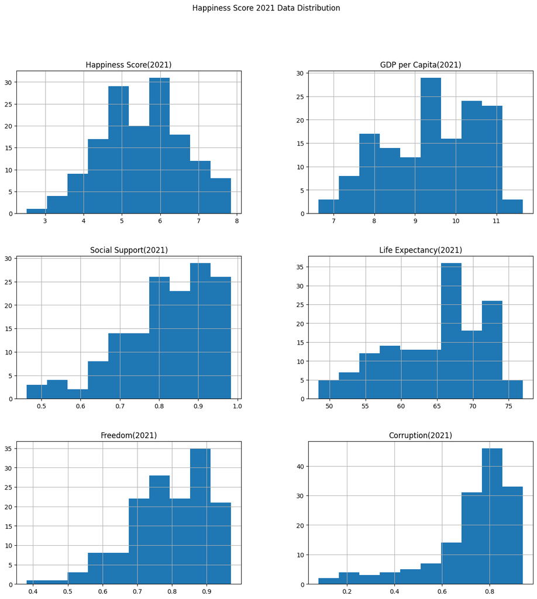

```python
# Visualize the happiness score 2021 data against all the other columns
happiness2021_final_df.hist(figsize=(15, 15))
plt.suptitle("Happiness Score 2021 Data Distribution")
plt.show()
```

**Interpretation:**

The histogram visualization above provides a succinct overview of the distribution of data for the Happiness Score in the year 2021 across various other columns in the dataset. Each subplot represents a different column, displaying the frequency distribution of values within that column. Notably, a common trend emerges where all variables tend to be skewed towards the right side of the histogram, indicating a concentration of higher values. This concise visualization aids in quickly understanding the spread and central tendencies of the dataset, facilitating the identification of any notable patterns or outliers. Such insights are essential for informing subsequent analysis and decision-making processes, making this visualization a valuable exploratory tool in data analysis workflows.

### Happiness Dataset - 2022

```python
# Read in the data
happiness2022_df = pd.read_csv('world_happiness_report_2022.csv')
happiness2022_df
```

|  | Unnamed: 0 | Happiness Rank | Country | Region | Happiness Score | Economy (GDP per Capita) | Family (Social Support) | Health (Life Expectancy) | Freedom | Trust (Government Corruption) | Generosity | Year |
| --- | --- | --- | --- | --- | --- | --- | --- | --- | --- | --- | --- | --- |
| 0 | 0 | 1 | Finland | Western Europe | 7,821 | 1,892 | 1,258 | 0,775 | 0,736 | 0,534 | 0,109 | 2022 |
| 1 | 1 | 2 | Denmark | Western Europe | 7,636 | 1,953 | 1,243 | 0,777 | 0,719 | 0,532 | 0,188 | 2022 |
| 2 | 2 | 3 | Iceland | Western Europe | 7,557 | 1,936 | 1,320 | 0,803 | 0,718 | 0,191 | 0,270 | 2022 |
| 3 | 3 | 4 | Switzerland | Western Europe | 7,512 | 2,026 | 1,226 | 0,822 | 0,677 | 0,461 | 0,147 | 2022 |
| 4 | 4 | 5 | Netherlands | Western Europe | 7,415 | 1,945 | 1,206 | 0,787 | 0,651 | 0,419 | 0,271 | 2022 |
| ... | ... | ... | ... | ... | ... | ... | ... | ... | ... | ... | ... | ... |
| 140 | 141 | 142 | Botswana | Sub-Saharan Africa | 3,471 | 1,503 | 0,815 | 0,280 | 0,571 | 0,102 | 0,012 | 2022 |
| 141 | 142 | 143 | Rwanda | Sub-Saharan Africa | 3,268 | 0,785 | 0,133 | 0,462 | 0,621 | 0,544 | 0,187 | 2022 |
| 142 | 143 | 144 | Zimbabwe | Sub-Saharan Africa | 2,995 | 0,947 | 0,690 | 0,270 | 0,329 | 0,105 | 0,106 | 2022 |
| 143 | 144 | 145 | Lebanon | Middle East and Northern Africa | 2,955 | 1,392 | 0,498 | 0,631 | 0,103 | 0,034 | 0,082 | 2022 |
| 144 | 145 | 146 | Afghanistan | Southern Asia | 2,404 | 0,758 | 0,000 | 0,289 | 0,000 | 0,005 | 0,089 | 2022 |

145 rows × 12 columns

```python
# Select the columns we want to keep
happiness2022_df = happiness2022_df[["Country", "Region", "Happiness Score", "Economy (GDP per Capita)", "Family (Social Support)",
                                     "Health (Life Expectancy)", "Freedom", "Trust (Government Corruption)"]]
happiness2022_df
```

|  | Country | Region | Happiness Score | Economy (GDP per Capita) | Family (Social Support) | Health (Life Expectancy) | Freedom | Trust (Government Corruption) |
| --- | --- | --- | --- | --- | --- | --- | --- | --- |
| 0 | Finland | Western Europe | 7,821 | 1,892 | 1,258 | 0,775 | 0,736 | 0,534 |
| 1 | Denmark | Western Europe | 7,636 | 1,953 | 1,243 | 0,777 | 0,719 | 0,532 |
| 2 | Iceland | Western Europe | 7,557 | 1,936 | 1,320 | 0,803 | 0,718 | 0,191 |
| 3 | Switzerland | Western Europe | 7,512 | 2,026 | 1,226 | 0,822 | 0,677 | 0,461 |
| 4 | Netherlands | Western Europe | 7,415 | 1,945 | 1,206 | 0,787 | 0,651 | 0,419 |
| ... | ... | ... | ... | ... | ... | ... | ... | ... |
| 140 | Botswana | Sub-Saharan Africa | 3,471 | 1,503 | 0,815 | 0,280 | 0,571 | 0,102 |
| 141 | Rwanda | Sub-Saharan Africa | 3,268 | 0,785 | 0,133 | 0,462 | 0,621 | 0,544 |
| 142 | Zimbabwe | Sub-Saharan Africa | 2,995 | 0,947 | 0,690 | 0,270 | 0,329 | 0,105 |
| 143 | Lebanon | Middle East and Northern Africa | 2,955 | 1,392 | 0,498 | 0,631 | 0,103 | 0,034 |
| 144 | Afghanistan | Southern Asia | 2,404 | 0,758 | 0,000 | 0,289 | 0,000 | 0,005 |

145 rows × 8 columns

```python
# Make a copy of the data frame
happiness2022_final_df = happiness2022_df.copy()

# Drop missing values
happiness2022_final_df.dropna(inplace=True)
```

```python
# Rename the columns to be more descriptive and consistent
happiness2022_final_df.rename(columns={"Happiness Score": "Happiness Score(2022)", "Economy (GDP per Capita)": "GDP per Capita(2022)", "Family (Social Support)": "Social Support(2022)",
                              "Health (Life Expectancy)": "Life Expectancy(2022)", "Freedom": "Freedom(2022)", "Trust (Government Corruption)": "Corruption(2022)"}, inplace=True)
happiness2022_final_df
```

|  | Country | Region | Happiness Score(2022) | GDP per Capita(2022) | Social Support(2022) | Life Expectancy(2022) | Freedom(2022) | Corruption(2022) |
| --- | --- | --- | --- | --- | --- | --- | --- | --- |
| 0 | Finland | Western Europe | 7,821 | 1,892 | 1,258 | 0,775 | 0,736 | 0,534 |
| 1 | Denmark | Western Europe | 7,636 | 1,953 | 1,243 | 0,777 | 0,719 | 0,532 |
| 2 | Iceland | Western Europe | 7,557 | 1,936 | 1,320 | 0,803 | 0,718 | 0,191 |
| 3 | Switzerland | Western Europe | 7,512 | 2,026 | 1,226 | 0,822 | 0,677 | 0,461 |
| 4 | Netherlands | Western Europe | 7,415 | 1,945 | 1,206 | 0,787 | 0,651 | 0,419 |
| ... | ... | ... | ... | ... | ... | ... | ... | ... |
| 140 | Botswana | Sub-Saharan Africa | 3,471 | 1,503 | 0,815 | 0,280 | 0,571 | 0,102 |
| 141 | Rwanda | Sub-Saharan Africa | 3,268 | 0,785 | 0,133 | 0,462 | 0,621 | 0,544 |
| 142 | Zimbabwe | Sub-Saharan Africa | 2,995 | 0,947 | 0,690 | 0,270 | 0,329 | 0,105 |
| 143 | Lebanon | Middle East and Northern Africa | 2,955 | 1,392 | 0,498 | 0,631 | 0,103 | 0,034 |
| 144 | Afghanistan | Southern Asia | 2,404 | 0,758 | 0,000 | 0,289 | 0,000 | 0,005 |

145 rows × 8 columns

```python
# Convert the 'GDP per Capita(2022)' column to an integer
happiness2022_final_df["GDP per Capita(2022)"] = happiness2022_final_df["GDP per Capita(2022)"].str.replace(
    ",", "").astype(int)

# Log transform the 'GDP per Capita(2022)' column
happiness2022_final_df["Logged GDP per Capita(2022)"] = np.log2(
    happiness2022_final_df["GDP per Capita(2022)"])

# Drop the 'GDP per Capita(2022)' column
happiness2022_final_df.drop(columns=["GDP per Capita(2022)"], inplace=True)

# Rename the 'Logged GDP per Capita(2022)' column to 'GDP per Capita(2022)'
happiness2022_final_df.rename(
    columns={"Logged GDP per Capita(2022)": "GDP per Capita(2022)"}, inplace=True)
happiness2022_final_df
```

```python
# Replace the commas with periods in every applicable column
happiness2022_final_df = happiness2022_final_df.replace(",", ".", regex=True)

# Convert the columns to float
happiness2022_final_df["Life Expectancy(2022)"] = happiness2022_final_df["Life Expectancy(2022)"].astype(
    float)

# Multiply the 'Life Expectancy(2022)' column by 100
happiness2022_final_df["Life Expectancy(2022)"] = happiness2022_final_df["Life Expectancy(2022)"] * 100
happiness2022_final_df
```

|  | Country | Region | Happiness Score(2022) | Social Support(2022) | Life Expectancy(2022) | Freedom(2022) | Corruption(2022) | GDP per Capita(2022) |
| --- | --- | --- | --- | --- | --- | --- | --- | --- |
| 0 | Finland | Western Europe | 7.821 | 1.258 | 77.5 | 0.736 | 0.534 | 10.885696 |
| 1 | Denmark | Western Europe | 7.636 | 1.243 | 77.7 | 0.719 | 0.532 | 10.931476 |
| 2 | Iceland | Western Europe | 7.557 | 1.320 | 80.3 | 0.718 | 0.191 | 10.918863 |
| 3 | Switzerland | Western Europe | 7.512 | 1.226 | 82.2 | 0.677 | 0.461 | 10.984418 |
| 4 | Netherlands | Western Europe | 7.415 | 1.206 | 78.7 | 0.651 | 0.419 | 10.925554 |
| ... | ... | ... | ... | ... | ... | ... | ... | ... |
| 140 | Botswana | Sub-Saharan Africa | 3.471 | 0.815 | 28.0 | 0.571 | 0.102 | 10.553629 |
| 141 | Rwanda | Sub-Saharan Africa | 3.268 | 0.133 | 46.2 | 0.621 | 0.544 | 9.616549 |
| 142 | Zimbabwe | Sub-Saharan Africa | 2.995 | 0.690 | 27.0 | 0.329 | 0.105 | 9.887221 |
| 143 | Lebanon | Middle East and Northern Africa | 2.955 | 0.498 | 63.1 | 0.103 | 0.034 | 10.442943 |
| 144 | Afghanistan | Southern Asia | 2.404 | 0.000 | 28.9 | 0.000 | 0.005 | 9.566054 |

145 rows × 8 columns

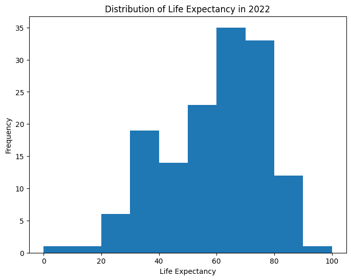

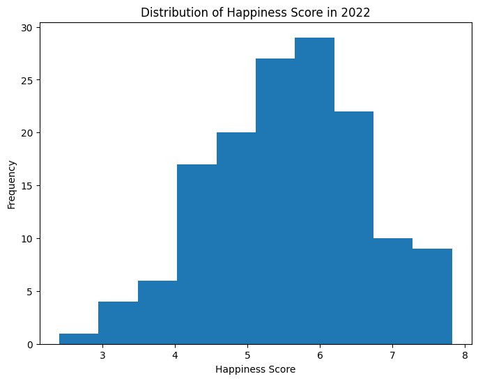

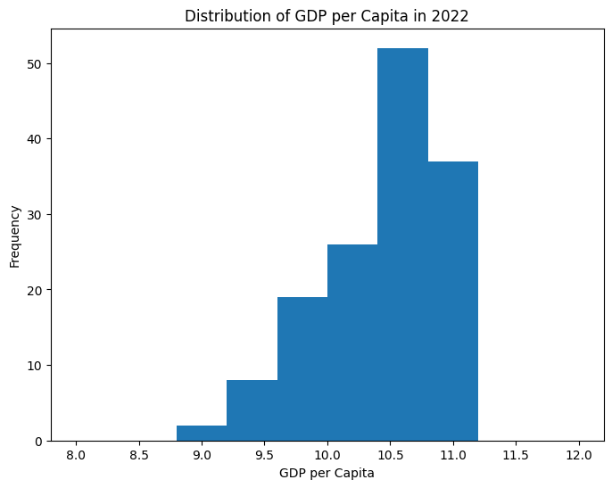

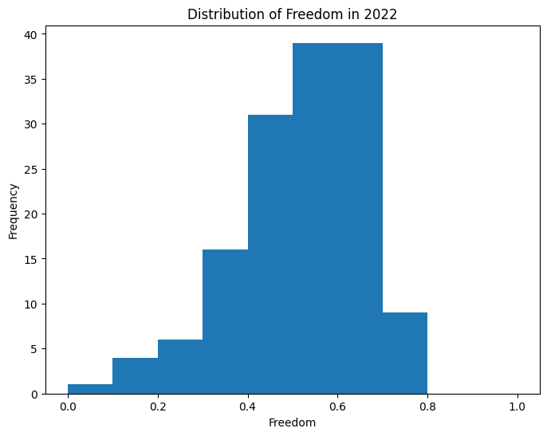

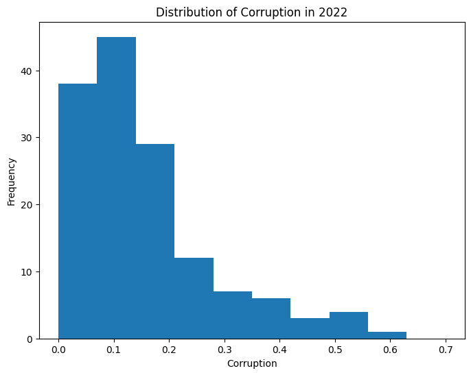

```python
# Convert the 'Happiness Score(2022)', 'Freedom(2022)' and 'Corruption(2022)' columns to float
happiness2022_final_df["Happiness Score(2022)"] = happiness2022_final_df["Happiness Score(2022)"].astype(
    float)
happiness2022_final_df["Freedom(2022)"] = happiness2022_final_df["Freedom(2022)"].astype(
    float)
happiness2022_final_df["Corruption(2022)"] = happiness2022_final_df["Corruption(2022)"].astype(
    float)

# Visualize the Life Expectancy data
happiness2022_final_df["Life Expectancy(2022)"].plot(
    kind="hist", figsize=(8, 6), range=(0, 100))
plt.xlabel("Life Expectancy")
plt.ylabel("Frequency")
plt.title("Distribution of Life Expectancy in 2022")
plt.show()

# Visualize the Happiness Score
happiness2022_final_df["Happiness Score(2022)"].plot(
    kind="hist", figsize=(8, 6))
plt.xlabel("Happiness Score")
plt.ylabel("Frequency")
plt.title("Distribution of Happiness Score in 2022")
plt.show()

# Visualize the GDP per Capita
happiness2022_final_df["GDP per Capita(2022)"].plot(
    kind="hist", figsize=(8, 6), range=(8, 12))
plt.xlabel("GDP per Capita")
plt.ylabel("Frequency")
plt.title("Distribution of GDP per Capita in 2022")
plt.show()

# Visualize the Freedom data
happiness2022_final_df["Freedom(2022)"].plot(
    kind="hist", figsize=(8, 6), range=(0, 1))
plt.xlabel("Freedom")
plt.ylabel("Frequency")
plt.title("Distribution of Freedom in 2022")
plt.show()

# Visualize the Corruption data
happiness2022_final_df["Corruption(2022)"].plot(
    kind="hist", figsize=(8, 6), range=(0, 0.7))
plt.xlabel("Corruption")
plt.ylabel("Frequency")
plt.title("Distribution of Corruption in 2022")
plt.show()
```

**Interpretation:**

The histogram visualization above provides a succinct overview of the distribution of data for the Happiness Score in the year 2022 across various other columns in the dataset. Each subplot represents a different column, displaying the frequency distribution of values within that column. Notably, a common trend emerges where all variables tend to be skewed towards the right side of the histogram, indicating a concentration of higher values, except for "Corruption". This concise visualization aids in quickly understanding the spread and central tendencies of the dataset, facilitating the identification of any notable patterns or outliers. Such insights are essential for informing subsequent analysis and decision-making processes, making this visualization a valuable exploratory tool in data analysis workflows.

### Happiness Dataset - 2023

```python
# Read in the data
happiness2023_df = pd.read_csv('world_happiness_report_2023.csv')
happiness2023_df
```

|  | Country name | Ladder score | Standard error of ladder score | upperwhisker | lowerwhisker | Logged GDP per capita | Social support | Healthy life expectancy | Freedom to make life choices | Generosity | Perceptions of corruption | Ladder score in Dystopia | Explained by: Log GDP per capita | Explained by: Social support | Explained by: Healthy life expectancy | Explained by: Freedom to make life choices | Explained by: Generosity | Explained by: Perceptions of corruption | Dystopia + residual |
| --- | --- | --- | --- | --- | --- | --- | --- | --- | --- | --- | --- | --- | --- | --- | --- | --- | --- | --- | --- |
| 0 | Finland | 7.804 | 0.036 | 7.875 | 7.733 | 10.792 | 0.969 | 71.150 | 0.961 | -0.019 | 0.182 | 1.778 | 1.888 | 1.585 | 0.535 | 0.772 | 0.126 | 0.535 | 2.363 |
| 1 | Denmark | 7.586 | 0.041 | 7.667 | 7.506 | 10.962 | 0.954 | 71.250 | 0.934 | 0.134 | 0.196 | 1.778 | 1.949 | 1.548 | 0.537 | 0.734 | 0.208 | 0.525 | 2.084 |
| 2 | Iceland | 7.530 | 0.049 | 7.625 | 7.434 | 10.896 | 0.983 | 72.050 | 0.936 | 0.211 | 0.668 | 1.778 | 1.926 | 1.620 | 0.559 | 0.738 | 0.250 | 0.187 | 2.250 |
| 3 | Israel | 7.473 | 0.032 | 7.535 | 7.411 | 10.639 | 0.943 | 72.697 | 0.809 | -0.023 | 0.708 | 1.778 | 1.833 | 1.521 | 0.577 | 0.569 | 0.124 | 0.158 | 2.691 |
| 4 | Netherlands | 7.403 | 0.029 | 7.460 | 7.346 | 10.942 | 0.930 | 71.550 | 0.887 | 0.213 | 0.379 | 1.778 | 1.942 | 1.488 | 0.545 | 0.672 | 0.251 | 0.394 | 2.110 |
| ... | ... | ... | ... | ... | ... | ... | ... | ... | ... | ... | ... | ... | ... | ... | ... | ... | ... | ... | ... |
| 132 | Congo (Kinshasa) | 3.207 | 0.095 | 3.394 | 3.020 | 7.007 | 0.652 | 55.375 | 0.664 | 0.086 | 0.834 | 1.778 | 0.531 | 0.784 | 0.105 | 0.375 | 0.183 | 0.068 | 1.162 |
| 133 | Zimbabwe | 3.204 | 0.061 | 3.323 | 3.084 | 7.641 | 0.690 | 54.050 | 0.654 | -0.046 | 0.766 | 1.778 | 0.758 | 0.881 | 0.069 | 0.363 | 0.112 | 0.117 | 0.905 |
| 134 | Sierra Leone | 3.138 | 0.082 | 3.299 | 2.976 | 7.394 | 0.555 | 54.900 | 0.660 | 0.105 | 0.858 | 1.778 | 0.670 | 0.540 | 0.092 | 0.371 | 0.193 | 0.051 | 1.221 |
| 135 | Lebanon | 2.392 | 0.044 | 2.479 | 2.305 | 9.478 | 0.530 | 66.149 | 0.474 | -0.141 | 0.891 | 1.778 | 1.417 | 0.476 | 0.398 | 0.123 | 0.061 | 0.027 | -0.110 |
| 136 | Afghanistan | 1.859 | 0.033 | 1.923 | 1.795 | 7.324 | 0.341 | 54.712 | 0.382 | -0.081 | 0.847 | 1.778 | 0.645 | 0.000 | 0.087 | 0.000 | 0.093 | 0.059 | 0.976 |

137 rows × 19 columns

```python
# Pip install the pycountry-convert library
!pip install pycountry-convert
```

```python
# Select the columns we want to keep
happiness2023_refined_df = happiness2023_df[["Country name", "Ladder score", "Logged GDP per capita", "Social support",
                                             "Healthy life expectancy", "Freedom to make life choices", "Perceptions of corruption"]]
happiness2023_refined_df
```

|  | Country name | Ladder score | Logged GDP per capita | Social support | Healthy life expectancy | Freedom to make life choices | Perceptions of corruption |
| --- | --- | --- | --- | --- | --- | --- | --- |
| 0 | Finland | 7.804 | 10.792 | 0.969 | 71.150 | 0.961 | 0.182 |
| 1 | Denmark | 7.586 | 10.962 | 0.954 | 71.250 | 0.934 | 0.196 |
| 2 | Iceland | 7.530 | 10.896 | 0.983 | 72.050 | 0.936 | 0.668 |
| 3 | Israel | 7.473 | 10.639 | 0.943 | 72.697 | 0.809 | 0.708 |
| 4 | Netherlands | 7.403 | 10.942 | 0.930 | 71.550 | 0.887 | 0.379 |
| ... | ... | ... | ... | ... | ... | ... | ... |
| 132 | Congo (Kinshasa) | 3.207 | 7.007 | 0.652 | 55.375 | 0.664 | 0.834 |
| 133 | Zimbabwe | 3.204 | 7.641 | 0.690 | 54.050 | 0.654 | 0.766 |
| 134 | Sierra Leone | 3.138 | 7.394 | 0.555 | 54.900 | 0.660 | 0.858 |
| 135 | Lebanon | 2.392 | 9.478 | 0.530 | 66.149 | 0.474 | 0.891 |
| 136 | Afghanistan | 1.859 | 7.324 | 0.341 | 54.712 | 0.382 | 0.847 |

137 rows × 7 columns

```python
# Make a copy of the data frame
happiness2023_final_df = happiness2023_refined_df.copy()

# Drop missing values
happiness2023_final_df.dropna(inplace=True)
```

```python
# Rename the columns to be more descriptive and consistent
happiness2023_final_df.rename(columns={"Country name": "Country", "Ladder score": "Happiness Score(2023)", "Logged GDP per capita": "GDP per Capita(2023)",
                                       "Social support": "Social Support(2023)", "Healthy life expectancy": "Life Expectancy(2023)", "Freedom to make life choices": "Freedom(2023)",
                                       "Perceptions of corruption": "Corruption(2023)"}, inplace=True)

# Merge the 'Region' column from the 'region_df' data frame with the 'happiness2023_final_df' data frame
happiness2023_final_df = happiness2023_final_df.merge(
    region_df, on='Country', how='left')
happiness2023_final_df
```

|  | Country | Happiness Score(2023) | GDP per Capita(2023) | Social Support(2023) | Life Expectancy(2023) | Freedom(2023) | Corruption(2023) | Region |
| --- | --- | --- | --- | --- | --- | --- | --- | --- |
| 0 | Finland | 7.804 | 10.792 | 0.969 | 71.150 | 0.961 | 0.182 | Western Europe |
| 1 | Denmark | 7.586 | 10.962 | 0.954 | 71.250 | 0.934 | 0.196 | Western Europe |
| 2 | Iceland | 7.530 | 10.896 | 0.983 | 72.050 | 0.936 | 0.668 | Western Europe |
| 3 | Israel | 7.473 | 10.639 | 0.943 | 72.697 | 0.809 | 0.708 | Middle East and North Africa |
| 4 | Netherlands | 7.403 | 10.942 | 0.930 | 71.550 | 0.887 | 0.379 | Western Europe |
| ... | ... | ... | ... | ... | ... | ... | ... | ... |
| 131 | Congo (Kinshasa) | 3.207 | 7.007 | 0.652 | 55.375 | 0.664 | 0.834 | NaN |
| 132 | Zimbabwe | 3.204 | 7.641 | 0.690 | 54.050 | 0.654 | 0.766 | Sub-Saharan Africa |
| 133 | Sierra Leone | 3.138 | 7.394 | 0.555 | 54.900 | 0.660 | 0.858 | Sub-Saharan Africa |
| 134 | Lebanon | 2.392 | 9.478 | 0.530 | 66.149 | 0.474 | 0.891 | Middle East and North Africa |
| 135 | Afghanistan | 1.859 | 7.324 | 0.341 | 54.712 | 0.382 | 0.847 | South Asia |

136 rows × 8 columns

```python
# Match the countries to their respective regions
region_mapping = {
    "Czechia": "Central and Eastern Europe",
    "State of Palestine": "Middle East and Northern Africa",
    "Turkiye": "Middle East and Northern Africa",
    "Congo (Kinshasa)": "Sub-Saharan Africa"
}

# Supply the region_mapping dictionary to the 'Region' column
happiness2023_final_df["Region"] = happiness2023_final_df["Region"].replace(
    region_mapping)

# Fill the missing values in the 'Region' column with the values from the 'Country' column
happiness2023_final_df["Region"] = happiness2023_final_df["Region"].fillna(
    happiness2023_final_df["Country"].map(region_mapping))
happiness2023_final_df
```

|  | Country | Happiness Score(2023) | GDP per Capita(2023) | Social Support(2023) | Life Expectancy(2023) | Freedom(2023) | Corruption(2023) | Region |
| --- | --- | --- | --- | --- | --- | --- | --- | --- |
| 0 | Finland | 7.804 | 10.792 | 0.969 | 71.150 | 0.961 | 0.182 | Western Europe |
| 1 | Denmark | 7.586 | 10.962 | 0.954 | 71.250 | 0.934 | 0.196 | Western Europe |
| 2 | Iceland | 7.530 | 10.896 | 0.983 | 72.050 | 0.936 | 0.668 | Western Europe |
| 3 | Israel | 7.473 | 10.639 | 0.943 | 72.697 | 0.809 | 0.708 | Middle East and North Africa |
| 4 | Netherlands | 7.403 | 10.942 | 0.930 | 71.550 | 0.887 | 0.379 | Western Europe |
| ... | ... | ... | ... | ... | ... | ... | ... | ... |
| 131 | Congo (Kinshasa) | 3.207 | 7.007 | 0.652 | 55.375 | 0.664 | 0.834 | Sub-Saharan Africa |
| 132 | Zimbabwe | 3.204 | 7.641 | 0.690 | 54.050 | 0.654 | 0.766 | Sub-Saharan Africa |
| 133 | Sierra Leone | 3.138 | 7.394 | 0.555 | 54.900 | 0.660 | 0.858 | Sub-Saharan Africa |
| 134 | Lebanon | 2.392 | 9.478 | 0.530 | 66.149 | 0.474 | 0.891 | Middle East and North Africa |
| 135 | Afghanistan | 1.859 | 7.324 | 0.341 | 54.712 | 0.382 | 0.847 | South Asia |

136 rows × 8 columns

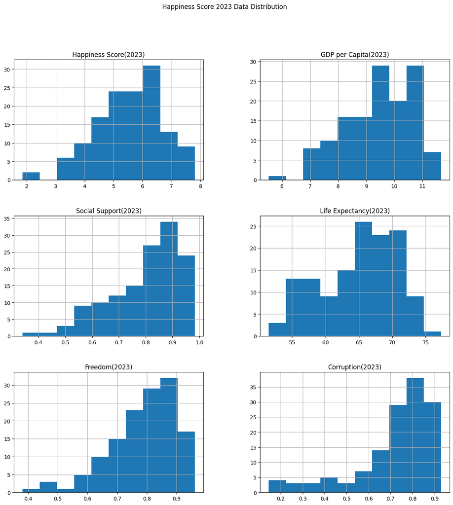

```python
# Visualize the happiness score 2023 data against all the other columns
happiness2023_final_df.hist(figsize=(15, 15))
plt.suptitle("Happiness Score 2023 Data Distribution")
plt.show()
```

**Interpretation:**

The histogram visualization above provides a succinct overview of the distribution of data for the Happiness Score in the year 2023 across various other columns in the dataset. Each subplot represents a different column, displaying the frequency distribution of values within that column. Notably, a common trend emerges where all variables tend to be skewed towards the right side of the histogram, indicating a concentration of higher values. This concise visualization aids in quickly understanding the spread and central tendencies of the dataset, facilitating the identification of any notable patterns or outliers. Such insights are essential for informing subsequent analysis and decision-making processes, making this visualization a valuable exploratory tool in data analysis workflows.

# Data Merging

```python
# Merge the three World Happiness Reports into one data frame
merged_happiness_df_1 = happiness2020_final_df.merge(
    happiness2021_final_df, on=["Country", "Region"], how="inner")
merged_happiness_df_2 = merged_happiness_df_1.merge(
    happiness2022_final_df, on=["Country", "Region"], how="inner")
merged_happiness_final_df = merged_happiness_df_2.merge(
    happiness2023_final_df, on=["Country", "Region"], how="inner")
merged_happiness_final_df
```

|  | Country | Region | Happiness Score(2020) | GDP per Capita(2020) | Social Support(2020) | Life Expectancy(2020) | Freedom(2020) | Corruption(2020) | Happiness Score(2021) | GDP per Capita(2021) | ... | Life Expectancy(2022) | Freedom(2022) | Corruption(2022) | GDP per Capita(2022) | Happiness Score(2023) | GDP per Capita(2023) | Social Support(2023) | Life Expectancy(2023) | Freedom(2023) | Corruption(2023) |
| --- | --- | --- | --- | --- | --- | --- | --- | --- | --- | --- | --- | --- | --- | --- | --- | --- | --- | --- | --- | --- | --- |
| 0 | Finland | Western Europe | 7.8087 | 10.639267 | 0.954330 | 71.900825 | 0.949172 | 0.195445 | 7.842 | 10.775 | ... | 77.5 | 0.736 | 0.534 | 10.885696 | 7.804 | 10.792 | 0.969 | 71.150 | 0.961 | 0.182 |
| 1 | Denmark | Western Europe | 7.6456 | 10.774001 | 0.955991 | 72.402504 | 0.951444 | 0.168489 | 7.620 | 10.933 | ... | 77.7 | 0.719 | 0.532 | 10.931476 | 7.586 | 10.962 | 0.954 | 71.250 | 0.934 | 0.196 |
| 2 | Switzerland | Western Europe | 7.5599 | 10.979933 | 0.942847 | 74.102448 | 0.921337 | 0.303728 | 7.571 | 11.117 | ... | 82.2 | 0.677 | 0.461 | 10.984418 | 7.240 | 11.164 | 0.920 | 72.900 | 0.891 | 0.266 |
| 3 | Iceland | Western Europe | 7.5045 | 10.772559 | 0.974670 | 73.000000 | 0.948892 | 0.711710 | 7.554 | 10.878 | ... | 80.3 | 0.718 | 0.191 | 10.918863 | 7.530 | 10.896 | 0.983 | 72.050 | 0.936 | 0.668 |
| 4 | Norway | Western Europe | 7.4880 | 11.087804 | 0.952487 | 73.200783 | 0.955750 | 0.263218 | 7.392 | 11.053 | ... | 78.6 | 0.728 | 0.474 | 10.963619 | 7.315 | 11.088 | 0.943 | 71.500 | 0.947 | 0.283 |
| ... | ... | ... | ... | ... | ... | ... | ... | ... | ... | ... | ... | ... | ... | ... | ... | ... | ... | ... | ... | ... | ... |
| 80 | Zambia | Sub-Saharan Africa | 3.7594 | 8.224720 | 0.698824 | 55.299377 | 0.806500 | 0.801290 | 4.073 | 8.145 | ... | 30.6 | 0.525 | 0.083 | 9.861087 | 3.982 | 8.074 | 0.694 | 55.032 | 0.791 | 0.818 |
| 81 | Malawi | Sub-Saharan Africa | 3.5380 | 7.062226 | 0.544007 | 57.592888 | 0.803223 | 0.731701 | 3.600 | 6.958 | ... | 38.8 | 0.477 | 0.157 | 9.339850 | 3.495 | 7.302 | 0.531 | 58.475 | 0.750 | 0.749 |
| 82 | Botswana | Sub-Saharan Africa | 3.4789 | 9.711204 | 0.779122 | 58.924454 | 0.821328 | 0.777931 | 3.467 | 9.782 | ... | 28.0 | 0.571 | 0.102 | 10.553629 | 3.435 | 9.629 | 0.753 | 54.725 | 0.742 | 0.830 |
| 83 | Tanzania | Sub-Saharan Africa | 3.4762 | 7.967665 | 0.688933 | 57.496075 | 0.821540 | 0.619799 | 3.623 | 7.876 | ... | 42.5 | 0.578 | 0.270 | 9.727920 | 3.694 | 7.857 | 0.653 | 59.401 | 0.838 | 0.554 |
| 84 | Zimbabwe | Sub-Saharan Africa | 3.2992 | 7.865712 | 0.763093 | 55.617260 | 0.711458 | 0.810237 | 3.145 | 7.943 | ... | 27.0 | 0.329 | 0.105 | 9.887221 | 3.204 | 7.641 | 0.690 | 54.050 | 0.654 | 0.766 |

85 rows × 26 columns

```python
# Merge the happiness and income data frames
merged_happiness_income_df = merged_happiness_final_df.merge(
    income_final_df, on="Country", how="inner")
merged_happiness_income_df
```

|  | Country | Region | Happiness Score(2020) | GDP per Capita(2020) | Social Support(2020) | Life Expectancy(2020) | Freedom(2020) | Corruption(2020) | Happiness Score(2021) | GDP per Capita(2021) | ... | Freedom(2022) | Corruption(2022) | GDP per Capita(2022) | Happiness Score(2023) | GDP per Capita(2023) | Social Support(2023) | Life Expectancy(2023) | Freedom(2023) | Corruption(2023) | Income Group |
| --- | --- | --- | --- | --- | --- | --- | --- | --- | --- | --- | --- | --- | --- | --- | --- | --- | --- | --- | --- | --- | --- |
| 0 | Finland | Western Europe | 7.8087 | 10.639267 | 0.954330 | 71.900825 | 0.949172 | 0.195445 | 7.842 | 10.775 | ... | 0.736 | 0.534 | 10.885696 | 7.804 | 10.792 | 0.969 | 71.150 | 0.961 | 0.182 | High income |
| 1 | Denmark | Western Europe | 7.6456 | 10.774001 | 0.955991 | 72.402504 | 0.951444 | 0.168489 | 7.620 | 10.933 | ... | 0.719 | 0.532 | 10.931476 | 7.586 | 10.962 | 0.954 | 71.250 | 0.934 | 0.196 | High income |
| 2 | Switzerland | Western Europe | 7.5599 | 10.979933 | 0.942847 | 74.102448 | 0.921337 | 0.303728 | 7.571 | 11.117 | ... | 0.677 | 0.461 | 10.984418 | 7.240 | 11.164 | 0.920 | 72.900 | 0.891 | 0.266 | High income |
| 3 | Iceland | Western Europe | 7.5045 | 10.772559 | 0.974670 | 73.000000 | 0.948892 | 0.711710 | 7.554 | 10.878 | ... | 0.718 | 0.191 | 10.918863 | 7.530 | 10.896 | 0.983 | 72.050 | 0.936 | 0.668 | High income |
| 4 | Norway | Western Europe | 7.4880 | 11.087804 | 0.952487 | 73.200783 | 0.955750 | 0.263218 | 7.392 | 11.053 | ... | 0.728 | 0.474 | 10.963619 | 7.315 | 11.088 | 0.943 | 71.500 | 0.947 | 0.283 | High income |
| ... | ... | ... | ... | ... | ... | ... | ... | ... | ... | ... | ... | ... | ... | ... | ... | ... | ... | ... | ... | ... | ... |
| 76 | Sierra Leone | Sub-Saharan Africa | 3.9264 | 7.268803 | 0.636142 | 50.865143 | 0.715315 | 0.861331 | 3.849 | 7.434 | ... | 0.387 | 0.055 | 9.422065 | 3.138 | 7.394 | 0.555 | 54.900 | 0.660 | 0.858 | Low income |
| 77 | Zambia | Sub-Saharan Africa | 3.7594 | 8.224720 | 0.698824 | 55.299377 | 0.806500 | 0.801290 | 4.073 | 8.145 | ... | 0.525 | 0.083 | 9.861087 | 3.982 | 8.074 | 0.694 | 55.032 | 0.791 | 0.818 | Lower middle income |
| 78 | Malawi | Sub-Saharan Africa | 3.5380 | 7.062226 | 0.544007 | 57.592888 | 0.803223 | 0.731701 | 3.600 | 6.958 | ... | 0.477 | 0.157 | 9.339850 | 3.495 | 7.302 | 0.531 | 58.475 | 0.750 | 0.749 | Low income |
| 79 | Botswana | Sub-Saharan Africa | 3.4789 | 9.711204 | 0.779122 | 58.924454 | 0.821328 | 0.777931 | 3.467 | 9.782 | ... | 0.571 | 0.102 | 10.553629 | 3.435 | 9.629 | 0.753 | 54.725 | 0.742 | 0.830 | Upper middle income |
| 80 | Zimbabwe | Sub-Saharan Africa | 3.2992 | 7.865712 | 0.763093 | 55.617260 | 0.711458 | 0.810237 | 3.145 | 7.943 | ... | 0.329 | 0.105 | 9.887221 | 3.204 | 7.641 | 0.690 | 54.050 | 0.654 | 0.766 | Lower middle income |

81 rows × 27 columns

```python
# Merge the merged_happiness_income_df and gdpgrowth_country_final_df data frames into one data frame
merged_happiness_income_gdp_df = merged_happiness_income_df.merge(
    gdpgrowth_country_final_df, on=["Country"], how="inner")
merged_happiness_income_gdp_df
```

|  | Country | Region | Happiness Score(2020) | GDP per Capita(2020) | Social Support(2020) | Life Expectancy(2020) | Freedom(2020) | Corruption(2020) | Happiness Score(2021) | GDP per Capita(2021) | ... | GDP per Capita(2023) | Social Support(2023) | Life Expectancy(2023) | Freedom(2023) | Corruption(2023) | Income Group | Annual GDP Growth(2020) | Annual GDP Growth(2021) | Annual GDP Growth(2022) | Annual GDP Growth(2023) |
| --- | --- | --- | --- | --- | --- | --- | --- | --- | --- | --- | --- | --- | --- | --- | --- | --- | --- | --- | --- | --- | --- |
| 0 | Finland | Western Europe | 7.8087 | 10.639267 | 0.954330 | 71.900825 | 0.949172 | 0.195445 | 7.842 | 10.775 | ... | 10.792 | 0.969 | 71.150 | 0.961 | 0.182 | High income | -2.4 | 3.2 | 1.6 | -0.1 |
| 1 | Denmark | Western Europe | 7.6456 | 10.774001 | 0.955991 | 72.402504 | 0.951444 | 0.168489 | 7.620 | 10.933 | ... | 10.962 | 0.954 | 71.250 | 0.934 | 0.196 | High income | -2.4 | 6.8 | 2.7 | 1.7 |
| 2 | Switzerland | Western Europe | 7.5599 | 10.979933 | 0.942847 | 74.102448 | 0.921337 | 0.303728 | 7.571 | 11.117 | ... | 11.164 | 0.920 | 72.900 | 0.891 | 0.266 | High income | -2.3 | 5.4 | 2.7 | 0.9 |
| 3 | Iceland | Western Europe | 7.5045 | 10.772559 | 0.974670 | 73.000000 | 0.948892 | 0.711710 | 7.554 | 10.878 | ... | 10.896 | 0.983 | 72.050 | 0.936 | 0.668 | High income | -7.2 | 4.5 | 7.2 | 3.3 |
| 4 | Norway | Western Europe | 7.4880 | 11.087804 | 0.952487 | 73.200783 | 0.955750 | 0.263218 | 7.392 | 11.053 | ... | 11.088 | 0.943 | 71.500 | 0.947 | 0.283 | High income | -1.3 | 3.9 | 3.3 | 2.3 |
| ... | ... | ... | ... | ... | ... | ... | ... | ... | ... | ... | ... | ... | ... | ... | ... | ... | ... | ... | ... | ... | ... |
| 73 | Madagascar | Sub-Saharan Africa | 4.1656 | 7.281686 | 0.668196 | 59.105427 | 0.557574 | 0.817486 | 4.208 | 7.396 | ... | 7.290 | 0.650 | 58.050 | 0.522 | 0.742 | Low income | -7.1 | 5.7 | 4.0 | 4.0 |
| 74 | Sierra Leone | Sub-Saharan Africa | 3.9264 | 7.268803 | 0.636142 | 50.865143 | 0.715315 | 0.861331 | 3.849 | 7.434 | ... | 7.394 | 0.555 | 54.900 | 0.660 | 0.858 | Low income | -2.0 | 4.1 | 4.0 | 2.7 |
| 75 | Zambia | Sub-Saharan Africa | 3.7594 | 8.224720 | 0.698824 | 55.299377 | 0.806500 | 0.801290 | 4.073 | 8.145 | ... | 8.074 | 0.694 | 55.032 | 0.791 | 0.818 | Lower middle income | -2.8 | 4.6 | 4.7 | 3.6 |
| 76 | Malawi | Sub-Saharan Africa | 3.5380 | 7.062226 | 0.544007 | 57.592888 | 0.803223 | 0.731701 | 3.600 | 6.958 | ... | 7.302 | 0.531 | 58.475 | 0.750 | 0.749 | Low income | 0.9 | 4.6 | 0.8 | 1.7 |
| 77 | Botswana | Sub-Saharan Africa | 3.4789 | 9.711204 | 0.779122 | 58.924454 | 0.821328 | 0.777931 | 3.467 | 9.782 | ... | 9.629 | 0.753 | 54.725 | 0.742 | 0.830 | Upper middle income | -8.7 | 11.9 | 5.8 | 3.8 |

78 rows × 31 columns

```python
# Reindex the columns
merged_happiness_income_gdp_df = merged_happiness_income_gdp_df.reindex(columns=["Country", "Region", "Income Group",
                                                                                 "Happiness Score(2020)", "Happiness Score(2021)", "Happiness Score(2022)", "Happiness Score(2023)",
                                                                                 "GDP per Capita(2020)", "Annual GDP Growth(2020)",
                                                                                 "GDP per Capita(2021)", "Annual GDP Growth(2021)",
                                                                                 "GDP per Capita(2022)", "Annual GDP Growth(2022)",
                                                                                 "GDP per Capita(2023)", "Annual GDP Growth(2023)",
                                                                                 "Social Support(2020)", "Social Support(2021)", "Social Support(2022)", "Social Support(2023)",
                                                                                 "Life Expectancy(2020)", "Life Expectancy(2021)", "Life Expectancy(2022)", "Life Expectancy(2023)",
                                                                                 "Freedom(2020)", "Freedom(2021)", "Freedom(2022)", "Freedom(2023)",
                                                                                 "Corruption(2020)", "Corruption(2021)", "Corruption(2022)", "Corruption(2023)"])

# Convert the 'Happiness Score(2022)' column to float
merged_happiness_income_gdp_df["Happiness Score(2022)"] = merged_happiness_income_gdp_df["Happiness Score(2022)"].astype(
    float)
merged_happiness_income_gdp_df
```

|  | Country | Region | Income Group | Happiness Score(2020) | Happiness Score(2021) | Happiness Score(2022) | Happiness Score(2023) | GDP per Capita(2020) | Annual GDP Growth(2020) | GDP per Capita(2021) | ... | Life Expectancy(2022) | Life Expectancy(2023) | Freedom(2020) | Freedom(2021) | Freedom(2022) | Freedom(2023) | Corruption(2020) | Corruption(2021) | Corruption(2022) | Corruption(2023) |
| --- | --- | --- | --- | --- | --- | --- | --- | --- | --- | --- | --- | --- | --- | --- | --- | --- | --- | --- | --- | --- | --- |
| 0 | Finland | Western Europe | High income | 7.8087 | 7.842 | 7.821 | 7.804 | 10.639267 | -2.4 | 10.775 | ... | 77.5 | 71.150 | 0.949172 | 0.949 | 0.736 | 0.961 | 0.195445 | 0.186 | 0.534 | 0.182 |
| 1 | Denmark | Western Europe | High income | 7.6456 | 7.620 | 7.636 | 7.586 | 10.774001 | -2.4 | 10.933 | ... | 77.7 | 71.250 | 0.951444 | 0.946 | 0.719 | 0.934 | 0.168489 | 0.179 | 0.532 | 0.196 |
| 2 | Switzerland | Western Europe | High income | 7.5599 | 7.571 | 7.512 | 7.240 | 10.979933 | -2.3 | 11.117 | ... | 82.2 | 72.900 | 0.921337 | 0.919 | 0.677 | 0.891 | 0.303728 | 0.292 | 0.461 | 0.266 |
| 3 | Iceland | Western Europe | High income | 7.5045 | 7.554 | 7.557 | 7.530 | 10.772559 | -7.2 | 10.878 | ... | 80.3 | 72.050 | 0.948892 | 0.955 | 0.718 | 0.936 | 0.711710 | 0.673 | 0.191 | 0.668 |
| 4 | Norway | Western Europe | High income | 7.4880 | 7.392 | 7.365 | 7.315 | 11.087804 | -1.3 | 11.053 | ... | 78.6 | 71.500 | 0.955750 | 0.960 | 0.728 | 0.947 | 0.263218 | 0.270 | 0.474 | 0.283 |
| ... | ... | ... | ... | ... | ... | ... | ... | ... | ... | ... | ... | ... | ... | ... | ... | ... | ... | ... | ... | ... | ... |
| 73 | Madagascar | Sub-Saharan Africa | Low income | 4.1656 | 4.208 | 4.339 | 4.019 | 7.281686 | -7.1 | 7.396 | ... | 37.8 | 58.050 | 0.557574 | 0.552 | 0.202 | 0.522 | 0.817486 | 0.803 | 0.154 | 0.742 |
| 74 | Sierra Leone | Sub-Saharan Africa | Low income | 3.9264 | 3.849 | 3.574 | 3.138 | 7.268803 | -2.0 | 7.434 | ... | 27.3 | 54.900 | 0.715315 | 0.717 | 0.387 | 0.660 | 0.861331 | 0.866 | 0.055 | 0.858 |
| 75 | Zambia | Sub-Saharan Africa | Lower middle income | 3.7594 | 4.073 | 3.760 | 3.982 | 8.224720 | -2.8 | 8.145 | ... | 30.6 | 55.032 | 0.806500 | 0.782 | 0.525 | 0.791 | 0.801290 | 0.823 | 0.083 | 0.818 |
| 76 | Malawi | Sub-Saharan Africa | Low income | 3.5380 | 3.600 | 3.750 | 3.495 | 7.062226 | 0.9 | 6.958 | ... | 38.8 | 58.475 | 0.803223 | 0.780 | 0.477 | 0.750 | 0.731701 | 0.729 | 0.157 | 0.749 |
| 77 | Botswana | Sub-Saharan Africa | Upper middle income | 3.4789 | 3.467 | 3.471 | 3.435 | 9.711204 | -8.7 | 9.782 | ... | 28.0 | 54.725 | 0.821328 | 0.824 | 0.571 | 0.742 | 0.777931 | 0.801 | 0.102 | 0.830 |

78 rows × 31 columns

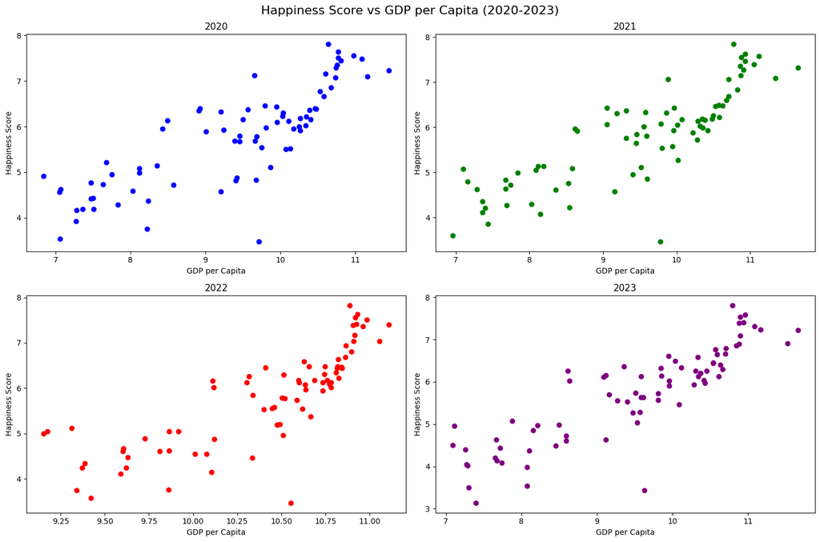

```python
# Visualize the merged data into four subplots showing the relationship between happiness score and GDP per capita for each year
fig, ax = plt.subplots(2, 2, figsize=(15, 10))
fig.suptitle('Happiness Score vs GDP per Capita (2020-2023)', fontsize=16)

# 2020
ax[0, 0].scatter(merged_happiness_income_gdp_df["GDP per Capita(2020)"],
                 merged_happiness_income_gdp_df["Happiness Score(2020)"], color='blue')
ax[0, 0].set_title('2020')
ax[0, 0].set_xlabel('GDP per Capita')
ax[0, 0].set_ylabel('Happiness Score')

# 2021
ax[0, 1].scatter(merged_happiness_income_gdp_df["GDP per Capita(2021)"],
                 merged_happiness_income_gdp_df["Happiness Score(2021)"], color='green')
ax[0, 1].set_title('2021')
ax[0, 1].set_xlabel('GDP per Capita')
ax[0, 1].set_ylabel('Happiness Score')

# 2022
ax[1, 0].scatter(merged_happiness_income_gdp_df["GDP per Capita(2022)"],
                 merged_happiness_income_gdp_df["Happiness Score(2022)"], color='red')
ax[1, 0].set_title('2022')
ax[1, 0].set_xlabel('GDP per Capita')
ax[1, 0].set_ylabel('Happiness Score')

# 2023
ax[1, 1].scatter(merged_happiness_income_gdp_df["GDP per Capita(2023)"],
                 merged_happiness_income_gdp_df["Happiness Score(2023)"], color='purple')
ax[1, 1].set_title('2023')
ax[1, 1].set_xlabel('GDP per Capita')
ax[1, 1].set_ylabel('Happiness Score')

plt.tight_layout()
plt.show()
```

**Interpretation:**

# Project Part II - Analysis

## Descriptive Statistics

```python
# Print the final layoff data frame
layoff_final_df
```

| Year | Canada | Germany | India | Singapore | United States |
| --- | --- | --- | --- | --- | --- |
| 2020 | 1141.0 | 331.0 | 9472.0 | 2361.0 | 45082.0 |
| 2021 | 45.0 | 87.0 | 200.0 | 21.0 | 6150.0 |
| 2022 | 3185.0 | 2424.0 | 9121.0 | 3484.0 | 97176.0 |
| 2023 | 4341.0 | 12278.0 | 6984.0 | 1169.0 | 136900.0 |

```python
# Compute descriptive statistics for the layoff data frame
layoff_final_df.describe()
```

|  | Canada | Germany | India | Singapore | United States |
| --- | --- | --- | --- | --- | --- |
| count | 4.000000 | 4.000000 | 4.000000 | 4.000000 | 4.000000 |
| mean | 2178.000000 | 3780.000000 | 6444.250000 | 1758.750000 | 71327.000000 |
| std | 1942.307562 | 5761.614068 | 4305.587407 | 1495.189258 | 57459.639412 |
| min | 45.000000 | 87.000000 | 200.000000 | 21.000000 | 6150.000000 |
| 25% | 867.000000 | 270.000000 | 5288.000000 | 882.000000 | 35349.000000 |
| 50% | 2163.000000 | 1377.500000 | 8052.500000 | 1765.000000 | 71129.000000 |
| 75% | 3474.000000 | 4887.500000 | 9208.750000 | 2641.750000 | 107107.000000 |
| max | 4341.000000 | 12278.000000 | 9472.000000 | 3484.000000 | 136900.000000 |

**Interpretation:**

The descriptive statistics for layoffs across different countries provide valuable insights into the labor market dynamics and economic conditions of each nation. Examining the data, we observe that Singapore has the lowest average number of layoffs, with a mean of 1,758.75. This suggests a relatively stable employment environment in Singapore compared to the other countries in the dataset. Canada follows closely with an average of 2,178 layoffs, indicating a somewhat higher level of job turnover. Germany exhibits a higher average at 3,780, reflecting a more active labor market. In contrast, India demonstrates a significantly higher average of 6,444.25 layoffs, indicating greater volatility in employment levels. Lastly, the United States shows the highest average number of layoffs, with a mean of 71,327, signaling substantial fluctuations in employment within the country. These findings shed light on the varying degrees of economic resilience and labor market stability across these nations, providing valuable insights for policymakers and stakeholders alike.

```python
# Function to calculate the mode
def calculate_mode(data):
    unique, counts = np.unique(data, return_counts=True)
    max_count_index = np.argmax(counts)
    return unique[max_count_index]


# Calculate descriptive statistics for each country's layoffs
stats_data = []

for country in layoff_final_df.columns:
    layoffs = layoff_final_df[country]
    stats_data.append({
        'Country': country,
        'Mean': np.mean(layoffs),
        'Median': np.median(layoffs),
        'Mode': calculate_mode(layoffs),
        'Range': np.max(layoffs) - np.min(layoffs),
        'Variance': np.var(layoffs),
        'Standard Deviation': np.std(layoffs)
    })

# Create a DataFrame from the collected statistics
stats_df = pd.DataFrame(stats_data)

# Display the DataFrame
stats_df
```

|  | Country | Mean | Median | Mode | Range | Variance | Standard Deviation |
| --- | --- | --- | --- | --- | --- | --- | --- |
| 0 | Canada | 2178.00 | 2163.0 | 45.0 | 4296.0 | 2.829419e+06 | 1682.087691 |
| 1 | Germany | 3780.00 | 1377.5 | 87.0 | 12191.0 | 2.489715e+07 | 4989.704150 |
| 2 | India | 6444.25 | 8052.5 | 200.0 | 9272.0 | 1.390356e+07 | 3728.748072 |
| 3 | Singapore | 1758.75 | 1765.0 | 21.0 | 3463.0 | 1.676693e+06 | 1294.871881 |
| 4 | United States | 71327.00 | 71129.0 | 6150.0 | 130750.0 | 2.476208e+09 | 49761.507423 |

**Interpretation:**

The summary statistics for layoffs across different countries offer valuable insights into the distribution and variability of layoff figures within each nation. Analyzing the data, we find that Singapore exhibits the lowest mean number of layoffs, with an average of 1,758.75, closely followed by Canada with 2,178 layoffs. These relatively lower mean values suggest a more stable employment environment in these countries compared to others in the dataset. In contrast, Germany and India demonstrate higher mean layoff figures of 3,780 and 6,444.25, respectively, indicating more dynamic labor markets with greater fluctuations in employment levels. The United States stands out with the highest mean number of layoffs at 71,327, reflecting substantial variability in job turnover within the country. The median values, which represent the midpoint of the layoff distribution, further reinforce these observations. Overall, these statistics provide valuable insights into the labor market dynamics and economic conditions across different nations, aiding policymakers and stakeholders in understanding and addressing employment challenges.

```python
# Print the merged data frame
merged_happiness_income_gdp_df
```

|  | Country | Region | Income Group | Happiness Score(2020) | Happiness Score(2021) | Happiness Score(2022) | Happiness Score(2023) | GDP per Capita(2020) | Annual GDP Growth(2020) | GDP per Capita(2021) | ... | Life Expectancy(2022) | Life Expectancy(2023) | Freedom(2020) | Freedom(2021) | Freedom(2022) | Freedom(2023) | Corruption(2020) | Corruption(2021) | Corruption(2022) | Corruption(2023) |
| --- | --- | --- | --- | --- | --- | --- | --- | --- | --- | --- | --- | --- | --- | --- | --- | --- | --- | --- | --- | --- | --- |
| 0 | Finland | Western Europe | High income | 7.8087 | 7.842 | 7.821 | 7.804 | 10.639267 | -2.4 | 10.775 | ... | 77.5 | 71.150 | 0.949172 | 0.949 | 0.736 | 0.961 | 0.195445 | 0.186 | 0.534 | 0.182 |
| 1 | Denmark | Western Europe | High income | 7.6456 | 7.620 | 7.636 | 7.586 | 10.774001 | -2.4 | 10.933 | ... | 77.7 | 71.250 | 0.951444 | 0.946 | 0.719 | 0.934 | 0.168489 | 0.179 | 0.532 | 0.196 |
| 2 | Switzerland | Western Europe | High income | 7.5599 | 7.571 | 7.512 | 7.240 | 10.979933 | -2.3 | 11.117 | ... | 82.2 | 72.900 | 0.921337 | 0.919 | 0.677 | 0.891 | 0.303728 | 0.292 | 0.461 | 0.266 |
| 3 | Iceland | Western Europe | High income | 7.5045 | 7.554 | 7.557 | 7.530 | 10.772559 | -7.2 | 10.878 | ... | 80.3 | 72.050 | 0.948892 | 0.955 | 0.718 | 0.936 | 0.711710 | 0.673 | 0.191 | 0.668 |
| 4 | Norway | Western Europe | High income | 7.4880 | 7.392 | 7.365 | 7.315 | 11.087804 | -1.3 | 11.053 | ... | 78.6 | 71.500 | 0.955750 | 0.960 | 0.728 | 0.947 | 0.263218 | 0.270 | 0.474 | 0.283 |
| ... | ... | ... | ... | ... | ... | ... | ... | ... | ... | ... | ... | ... | ... | ... | ... | ... | ... | ... | ... | ... | ... |
| 73 | Madagascar | Sub-Saharan Africa | Low income | 4.1656 | 4.208 | 4.339 | 4.019 | 7.281686 | -7.1 | 7.396 | ... | 37.8 | 58.050 | 0.557574 | 0.552 | 0.202 | 0.522 | 0.817486 | 0.803 | 0.154 | 0.742 |
| 74 | Sierra Leone | Sub-Saharan Africa | Low income | 3.9264 | 3.849 | 3.574 | 3.138 | 7.268803 | -2.0 | 7.434 | ... | 27.3 | 54.900 | 0.715315 | 0.717 | 0.387 | 0.660 | 0.861331 | 0.866 | 0.055 | 0.858 |
| 75 | Zambia | Sub-Saharan Africa | Lower middle income | 3.7594 | 4.073 | 3.760 | 3.982 | 8.224720 | -2.8 | 8.145 | ... | 30.6 | 55.032 | 0.806500 | 0.782 | 0.525 | 0.791 | 0.801290 | 0.823 | 0.083 | 0.818 |
| 76 | Malawi | Sub-Saharan Africa | Low income | 3.5380 | 3.600 | 3.750 | 3.495 | 7.062226 | 0.9 | 6.958 | ... | 38.8 | 58.475 | 0.803223 | 0.780 | 0.477 | 0.750 | 0.731701 | 0.729 | 0.157 | 0.749 |
| 77 | Botswana | Sub-Saharan Africa | Upper middle income | 3.4789 | 3.467 | 3.471 | 3.435 | 9.711204 | -8.7 | 9.782 | ... | 28.0 | 54.725 | 0.821328 | 0.824 | 0.571 | 0.742 | 0.777931 | 0.801 | 0.102 | 0.830 |

78 rows × 31 columns